# USA lennufirmade 2015. aasta lendude hilinemiste andmete analüüs

Projekt õppeaines RAM0580 Andmeanalüüs

Igor Kazantsev, Karina Piir, Anastasia Baumer

30.05.2025

Käesolevas õppematerjalis on esitatud andmestiku puhastamise, ettevalmistamise ja kirjeldava analüüsi läbiviimise skeem anndmestiku flights.csv näitel.

Andmestik sisaldab teavet erinevate lennufirmade lendude kohta, sealhulgas lennu kuupäeva, lennufirma ja lennunumbri, lennuki registreerimisnumbri, lähte- ja sihtlennujaama, plaanitud ja tegelike väljumis- ning saabumisaegade, lendude kestuse ja distantsi kohta.

Lisaks on andmestikus kajastatud erinevad viivituste ja tühistamiste põhjused, sealhulgas ilmastikuolud, turvakontroll, lennufirma sisemised probleemid ja muud tegurid. Andmestik võimaldab analüüsida lendude hilinemiste mustreid, määrata peamisi hilinemiste põhjuseid ning hinnata, kuidas erinevad tegurid mõjutavad lennugraafikut.

# 1. osa

# Andmete eeltöötlus

Andmete eeltöötluse etapil toimub andmete edasiseks analüüsiks ettevalmistamine: andmete lugemine, tunnuste tüüpide kontrollimine, puhastamine (vigaste väärtuste kontroll ja eemaldamine, duplikaatide eemaldamine, puuduvate väärtuste kontroll ja asendamine või eemaldamine, mittesobivate tunnuste kustutamine) ja ka tunnuste teisendamine ning uute tunnuste moodustamine.

## Andmete lugemine

Loeme andmeid R-i

```r
flights = read.csv("flights.csv", dec = ".")
```

```r
library(DT)
datatable(head(flights, 100), options = list(scrollX = TRUE, pageLength = 10, searching = FALSE, scrollY = 300))
```

|  | YEAR | MONTH | DAY | DAY_OF_WEEK | AIRLINE | FLIGHT_NUMBER | TAIL_NUMBER | ORIGIN_AIRPORT | DESTINATION_AIRPORT | SCHEDULED_DEPARTURE | DEPARTURE_TIME | DEPARTURE_DELAY | TAXI_OUT | WHEELS_OFF | SCHEDULED_TIME | ELAPSED_TIME | AIR_TIME | DISTANCE | WHEELS_ON | TAXI_IN | SCHEDULED_ARRIVAL | ARRIVAL_TIME | ARRIVAL_DELAY | DIVERTED | CANCELLED | CANCELLATION_REASON | AIR_SYSTEM_DELAY | SECURITY_DELAY | AIRLINE_DELAY | … |
| --- | --- | --- | --- | --- | --- | --- | --- | --- | --- | --- | --- | --- | --- | --- | --- | --- | --- | --- | --- | --- | --- | --- | --- | --- | --- | --- | --- | --- | --- | --- |
| 1 | 2015 | 1 | 1 | 4 | AS | 98 | N407AS | ANC | SEA | 5 | 2354 | -11 | 21 | 15 | 205 | 194 | 169 | 1448 | 404 | 4 | 430 | 408 | -22 | 0 | 0 |  |  |  |  | … |
| 2 | 2015 | 1 | 1 | 4 | AA | 2336 | N3KUAA | LAX | PBI | 10 | 2 | -8 | 12 | 14 | 280 | 279 | 263 | 2330 | 737 | 4 | 750 | 741 | -9 | 0 | 0 |  |  |  |  | … |
| 3 | 2015 | 1 | 1 | 4 | US | 840 | N171US | SFO | CLT | 20 | 18 | -2 | 16 | 34 | 286 | 293 | 266 | 2296 | 800 | 11 | 806 | 811 | 5 | 0 | 0 |  |  |  |  | … |
| 4 | 2015 | 1 | 1 | 4 | AA | 258 | N3HYAA | LAX | MIA | 20 | 15 | -5 | 15 | 30 | 285 | 281 | 258 | 2342 | 748 | 8 | 805 | 756 | -9 | 0 | 0 |  |  |  |  | … |
| 5 | 2015 | 1 | 1 | 4 | AS | 135 | N527AS | SEA | ANC | 25 | 24 | -1 | 11 | 35 | 235 | 215 | 199 | 1448 | 254 | 5 | 320 | 259 | -21 | 0 | 0 |  |  |  |  | … |
| 6 | 2015 | 1 | 1 | 4 | DL | 806 | N3730B | SFO | MSP | 25 | 20 | -5 | 18 | 38 | 217 | 230 | 206 | 1589 | 604 | 6 | 602 | 610 | 8 | 0 | 0 |  |  |  |  | … |
| 7 | 2015 | 1 | 1 | 4 | NK | 612 | N635NK | LAS | MSP | 25 | 19 | -6 | 11 | 30 | 181 | 170 | 154 | 1299 | 504 | 5 | 526 | 509 | -17 | 0 | 0 |  |  |  |  | … |
| 8 | 2015 | 1 | 1 | 4 | US | 2013 | N584UW | LAX | CLT | 30 | 44 | 14 | 13 | 57 | 273 | 249 | 228 | 2125 | 745 | 8 | 803 | 753 | -10 | 0 | 0 |  |  |  |  | … |
| 9 | 2015 | 1 | 1 | 4 | AA | 1112 | N3LAAA | SFO | DFW | 30 | 19 | -11 | 17 | 36 | 195 | 193 | 173 | 1464 | 529 | 3 | 545 | 532 | -13 | 0 | 0 |  |  |  |  | … |
| 10 | 2015 | 1 | 1 | 4 | DL | 1173 | N826DN | LAS | ATL | 30 | 33 | 3 | 12 | 45 | 221 | 203 | 186 | 1747 | 651 | 5 | 711 | 656 | -15 | 0 | 0 |  |  |  |  | … |

[output cut: 90 more lines]

## Andmestikust ülevaade

Andmestiku struktuuri ülevaade funktsiooniga *str()*

```r
str(flights)
```

```
## 'data.frame':    5819079 obs. of  31 variables:
##  $ YEAR               : int  2015 2015 2015 2015 2015 2015 2015 2015 2015 2015 ...
##  $ MONTH              : int  1 1 1 1 1 1 1 1 1 1 ...
##  $ DAY                : int  1 1 1 1 1 1 1 1 1 1 ...
##  $ DAY_OF_WEEK        : int  4 4 4 4 4 4 4 4 4 4 ...
##  $ AIRLINE            : chr  "AS" "AA" "US" "AA" ...
##  $ FLIGHT_NUMBER      : int  98 2336 840 258 135 806 612 2013 1112 1173 ...
##  $ TAIL_NUMBER        : chr  "N407AS" "N3KUAA" "N171US" "N3HYAA" ...
##  $ ORIGIN_AIRPORT     : chr  "ANC" "LAX" "SFO" "LAX" ...
##  $ DESTINATION_AIRPORT: chr  "SEA" "PBI" "CLT" "MIA" ...
##  $ SCHEDULED_DEPARTURE: int  5 10 20 20 25 25 25 30 30 30 ...
##  $ DEPARTURE_TIME     : int  2354 2 18 15 24 20 19 44 19 33 ...
##  $ DEPARTURE_DELAY    : int  -11 -8 -2 -5 -1 -5 -6 14 -11 3 ...
##  $ TAXI_OUT           : int  21 12 16 15 11 18 11 13 17 12 ...
##  $ WHEELS_OFF         : int  15 14 34 30 35 38 30 57 36 45 ...
```

[output cut: 17 more lines]

Funktsiooni str() rakendamise tulemusena saime teada, et andmestikus on 5 819 079 objekti ja 31 muutujat. Esimesed muutujad, nagu YEAR, MONTH ja DAY, määravad lennu kuupäeva, samas kui FLIGHT_NUMBER ja TAIL_NUMBER identifitseerivad konkreetse lennu ja lennuki. Tunnused ORIGIN_AIRPORT ja DESTINATION_AIRPORT näitavad lähtelennujaama ja sihtkohta.

Andmestik sisaldab ka ajapõhiseid tunnuseid, nagu SCHEDULED_DEPARTURE, DEPARTURE_TIME, SCHEDULED_ARRIVAL ja ARRIVAL_TIME, mis võimaldavad analüüsida lennugraafikute täpsust. Samuti on esindatud hilinemistega seotud tunnused, nagu DEPARTURE_DELAY, ARRIVAL_DELAY ja LATE_AIRCRAFT_DELAY.

Funktsiooni str() abil näeme iga tunnuse tüüpi ja esimesi väärtusi, mis võimaldab kontrollida, kas tunnuste tüübid on lugemisel õigesti määratud.

## Ülevaade funktsiooni skim() abil

```r
library(skimr)
skim(flights)
```

Data summary

| Name | flights |
| --- | --- |
| Number of rows | 5819079 |
| Number of columns | 31 |
| _______________________ |  |
| Column type frequency: |  |
| character | 5 |
| numeric | 26 |
| ________________________ |  |
| Group variables | None |

**Variable type: character**

| skim_variable | n_missing | complete_rate | min | max | empty | n_unique | whitespace |
| --- | --- | --- | --- | --- | --- | --- | --- |
| AIRLINE | 0 | 1 | 2 | 2 | 0 | 14 | 0 |
| TAIL_NUMBER | 0 | 1 | 0 | 6 | 14721 | 4898 | 0 |
| ORIGIN_AIRPORT | 0 | 1 | 3 | 5 | 0 | 628 | 0 |
| DESTINATION_AIRPORT | 0 | 1 | 3 | 5 | 0 | 629 | 0 |
| CANCELLATION_REASON | 0 | 1 | 0 | 1 | 5729195 | 5 | 0 |

**Variable type: numeric**

| skim_variable | n_missing | complete_rate | mean | sd | p0 | p25 | p50 | p75 | p100 | hist |
| --- | --- | --- | --- | --- | --- | --- | --- | --- | --- | --- |
| YEAR | 0 | 1.00 | 2015.00 | 0.00 | 2015 | 2015 | 2015 | 2015 | 2015 | ▁▁▇▁▁ |
| MONTH | 0 | 1.00 | 6.52 | 3.41 | 1 | 4 | 7 | 9 | 12 | ▇▆▆▆▇ |
| DAY | 0 | 1.00 | 15.70 | 8.78 | 1 | 8 | 16 | 23 | 31 | ▇▇▇▇▆ |
| DAY_OF_WEEK | 0 | 1.00 | 3.93 | 1.99 | 1 | 2 | 4 | 6 | 7 | ▇▅▅▅▇ |
| FLIGHT_NUMBER | 0 | 1.00 | 2173.09 | 1757.06 | 1 | 730 | 1690 | 3230 | 9855 | ▇▃▂▁▁ |
| SCHEDULED_DEPARTURE | 0 | 1.00 | 1329.60 | 483.75 | 1 | 917 | 1325 | 1730 | 2359 | ▁▇▇▇▅ |
| DEPARTURE_TIME | 86153 | 0.99 | 1335.20 | 496.42 | 1 | 921 | 1330 | 1740 | 2400 | ▁▇▇▇▅ |
| DEPARTURE_DELAY | 86153 | 0.99 | 9.37 | 37.08 | -82 | -5 | -2 | 7 | 1988 | ▇▁▁▁▁ |
| TAXI_OUT | 89047 | 0.98 | 16.07 | 8.90 | 1 | 11 | 14 | 19 | 225 | ▇▁▁▁▁ |
| WHEELS_OFF | 89047 | 0.98 | 1357.17 | 498.01 | 1 | 935 | 1343 | 1754 | 2400 | ▁▇▇▇▅ |
| SCHEDULED_TIME | 6 | 1.00 | 141.69 | 75.21 | 18 | 85 | 123 | 173 | 718 | ▇▃▁▁▁ |
| ELAPSED_TIME | 105071 | 0.98 | 137.01 | 74.21 | 14 | 82 | 118 | 168 | 766 | ▇▂▁▁▁ |
| AIR_TIME | 105071 | 0.98 | 113.51 | 72.23 | 7 | 60 | 94 | 144 | 690 | ▇▂▁▁▁ |
| DISTANCE | 0 | 1.00 | 822.36 | 607.78 | 21 | 373 | 647 | 1062 | 4983 | ▇▂▁▁▁ |
| WHEELS_ON | 92513 | 0.98 | 1471.47 | 522.19 | 1 | 1054 | 1509 | 1911 | 2400 | ▁▅▇▇▇ |
| TAXI_IN | 92513 | 0.98 | 7.43 | 5.64 | 1 | 4 | 6 | 9 | 248 | ▇▁▁▁▁ |
| SCHEDULED_ARRIVAL | 0 | 1.00 | 1493.81 | 507.16 | 1 | 1110 | 1520 | 1918 | 2400 | ▁▅▇▇▇ |
| ARRIVAL_TIME | 92513 | 0.98 | 1476.49 | 526.32 | 1 | 1059 | 1512 | 1917 | 2400 | ▁▅▇▇▇ |
| ARRIVAL_DELAY | 105071 | 0.98 | 4.41 | 39.27 | -87 | -13 | -5 | 8 | 1971 | ▇▁▁▁▁ |
| DIVERTED | 0 | 1.00 | 0.00 | 0.05 | 0 | 0 | 0 | 0 | 1 | ▇▁▁▁▁ |
| CANCELLED | 0 | 1.00 | 0.02 | 0.12 | 0 | 0 | 0 | 0 | 1 | ▇▁▁▁▁ |
| AIR_SYSTEM_DELAY | 4755640 | 0.18 | 13.48 | 28.00 | 0 | 0 | 2 | 18 | 1134 | ▇▁▁▁▁ |
| SECURITY_DELAY | 4755640 | 0.18 | 0.08 | 2.14 | 0 | 0 | 0 | 0 | 573 | ▇▁▁▁▁ |
| AIRLINE_DELAY | 4755640 | 0.18 | 18.97 | 48.16 | 0 | 0 | 2 | 19 | 1971 | ▇▁▁▁▁ |
| LATE_AIRCRAFT_DELAY | 4755640 | 0.18 | 23.47 | 43.20 | 0 | 0 | 3 | 29 | 1331 | ▇▁▁▁▁ |
| WEATHER_DELAY | 4755640 | 0.18 | 2.92 | 20.43 | 0 | 0 | 0 | 0 | 1211 | ▇▁▁▁▁ |

Peale andmestiku objektide ja tunnuste arvu annab funktsioon skim() teada, et andmestikus on 5 sümboltüüpi (tekstipõhist tunnust) ja 26 arvulist tunnust. Näeme iga tunnuse korral puuduvate väärtuste arvu, mis võimaldab hinnata vajadust puuduvate andmete käsitlemiseks. Iga mittearvulise tunnuse puhul on esitatud erinevate väärtuste arv ning ülevaade kõige sagedamini esinevatest väärtustest. Iga arvulise tunnuse puhul on toodud peamised arvkarakteristikud, nagu keskmine, mediaan, standardhälve ning väärtuste sagedusjaotus.

Näeme, et andmestikus on mitmeid probleemseid tunnuseid, kus esineb palju puuduvate väärtusi. Näiteks on DEPARTURE_TIME-l 86 153 puuduvat väärtust, ARRIVAL_TIME-l 92 513, ning hilinemise põhjustega seotud tunnustel, nagu AIR_SYSTEM_DELAY, WEATHER_DELAY ja LATE_AIRCRAFT_DELAY, on ligi 4,75 miljonit puuduvat väärtust, mis moodustab umbes 82% andmestikust. See viitab sellele, et viivituste andmeid ei ole kogutud kõigi lendude puhul, mistõttu on nende tunnuste käsitlemine analüüsis oluline.

## Ülevaade funktsiooni paketi *summarytools()* abil

```r
library(summarytools)
dfSummary(flights,plain.ascii = FALSE, style = "grid",tmp.img.dir  = "/tmp",graph.magnif = 0.85)
```

```
## temporary images written to 'C:\tmp'
```

### Data Frame Summary

#### flights

**Dimensions:** 5819079 x 31  
**Duplicates:** 0

No

Variable

Stats / Values

Freqs (% of Valid)

Graph

Valid

Missing

1

YEAR  
[integer]

1 distinct value

2015 : 5819079 (100.0%)

5819079  
(100.0%)

0  
(0.0%)

2

MONTH  
[integer]

Mean (sd) : 6.5 (3.4)  
min < med < max:  
1 < 7 < 12  
IQR (CV) : 5 (0.5)

12 distinct values

5819079  
(100.0%)

0  
(0.0%)

3

DAY  
[integer]

Mean (sd) : 15.7 (8.8)  
min < med < max:  
1 < 16 < 31  
IQR (CV) : 15 (0.6)

31 distinct values

5819079  
(100.0%)

0  
(0.0%)

4

DAY_OF_WEEK  
[integer]

Mean (sd) : 3.9 (2)  
min < med < max:  
1 < 4 < 7  
IQR (CV) : 4 (0.5)

1 : 865543 (14.9%)  
2 : 844600 (14.5%)  
3 : 855897 (14.7%)  
4 : 872521 (15.0%)  
5 : 862209 (14.8%)  
6 : 700545 (12.0%)  
7 : 817764 (14.1%)

5819079  
(100.0%)

0  
(0.0%)

5

AIRLINE  
[character]

1. WN  
2. DL  
3. AA  
4. OO  
5. EV  
6. UA  
7. MQ  
8. B6  
9. US  
10. AS  
[ 4 others ]

1261855 (21.7%)  
875881 (15.1%)  
725984 (12.5%)  
588353 (10.1%)  
571977 ( 9.8%)  
515723 ( 8.9%)  
294632 ( 5.1%)  
267048 ( 4.6%)  
198715 ( 3.4%)  
172521 ( 3.0%)  
346390 ( 6.0%)

5819079  
(100.0%)

0  
(0.0%)

6

FLIGHT_NUMBER  
[integer]

Mean (sd) : 2173.1 (1757.1)  
min < med < max:  
1 < 1690 < 9855  
IQR (CV) : 2500 (0.8)

6952 distinct values

5819079  
(100.0%)

0  
(0.0%)

7

TAIL_NUMBER  
[character]

1. (Empty string)  
2. N480HA  
3. N484HA  
4. N488HA  
5. N493HA  
6. N478HA  
7. N483HA  
8. N486HA  
9. N491HA  
10. N489HA  
[ 4888 others ]

14721 ( 0.3%)  
3768 ( 0.1%)  
3723 ( 0.1%)  
3723 ( 0.1%)  
3585 ( 0.1%)  
3577 ( 0.1%)  
3528 ( 0.1%)  
3513 ( 0.1%)  
3494 ( 0.1%)  
3477 ( 0.1%)  
5771970 (99.2%)

[figure not shown]

5819079  
(100.0%)

0  
(0.0%)

8

ORIGIN_AIRPORT  
[character]

1. ATL  
2. ORD  
3. DFW  
4. DEN  
5. LAX  
6. SFO  
7. PHX  
8. IAH  
9. LAS  
10. MSP  
[ 618 others ]

346836 ( 6.0%)  
285884 ( 4.9%)  
239551 ( 4.1%)  
196055 ( 3.4%)  
194673 ( 3.3%)  
148008 ( 2.5%)  
146815 ( 2.5%)  
146622 ( 2.5%)  
133181 ( 2.3%)  
112117 ( 1.9%)  
3869337 (66.5%)

5819079  
(100.0%)

0  
(0.0%)

9

DESTINATION_AIRPORT  
[character]

1. ATL  
2. ORD  
3. DFW  
4. DEN  
5. LAX  
6. SFO  
7. PHX  
8. IAH  
9. LAS  
10. MSP  
[ 619 others ]

346904 ( 6.0%)  
285906 ( 4.9%)  
239582 ( 4.1%)  
196010 ( 3.4%)  
194696 ( 3.3%)  
147966 ( 2.5%)  
146812 ( 2.5%)  
146683 ( 2.5%)  
133198 ( 2.3%)  
112128 ( 1.9%)  
3869194 (66.5%)

5819079  
(100.0%)

0  
(0.0%)

10

SCHEDULED_DEPARTURE  
[integer]

Mean (sd) : 1329.6 (483.8)  
min < med < max:  
1 < 1325 < 2359  
IQR (CV) : 813 (0.4)

1321 distinct values

5819079  
(100.0%)

0  
(0.0%)

11

DEPARTURE_TIME  
[integer]

Mean (sd) : 1335.2 (496.4)  
min < med < max:  
1 < 1330 < 2400  
IQR (CV) : 819 (0.4)

1440 distinct values

5732926  
(98.5%)

86153  
(1.5%)

12

DEPARTURE_DELAY  
[integer]

Mean (sd) : 9.4 (37.1)  
min < med < max:  
-82 < -2 < 1988  
IQR (CV) : 12 (4)

1217 distinct values

5732926  
(98.5%)

86153  
(1.5%)

13

TAXI_OUT  
[integer]

Mean (sd) : 16.1 (8.9)  
min < med < max:  
1 < 14 < 225  
IQR (CV) : 8 (0.6)

184 distinct values

5730032  
(98.5%)

89047  
(1.5%)

14

WHEELS_OFF  
[integer]

Mean (sd) : 1357.2 (498)  
min < med < max:  
1 < 1343 < 2400  
IQR (CV) : 819 (0.4)

1440 distinct values

5730032  
(98.5%)

89047  
(1.5%)

15

SCHEDULED_TIME  
[integer]

Mean (sd) : 141.7 (75.2)  
min < med < max:  
18 < 123 < 718  
IQR (CV) : 88 (0.5)

550 distinct values

5819073  
(100.0%)

6  
(0.0%)

16

ELAPSED_TIME  
[integer]

Mean (sd) : 137 (74.2)  
min < med < max:  
14 < 118 < 766  
IQR (CV) : 86 (0.5)

712 distinct values

5714008  
(98.2%)

105071  
(1.8%)

17

AIR_TIME  
[integer]

Mean (sd) : 113.5 (72.2)  
min < med < max:  
7 < 94 < 690  
IQR (CV) : 84 (0.6)

675 distinct values

5714008  
(98.2%)

105071  
(1.8%)

18

DISTANCE  
[integer]

Mean (sd) : 822.4 (607.8)  
min < med < max:  
21 < 647 < 4983  
IQR (CV) : 689 (0.7)

1363 distinct values

5819079  
(100.0%)

0  
(0.0%)

19

WHEELS_ON  
[integer]

Mean (sd) : 1471.5 (522.2)  
min < med < max:  
1 < 1509 < 2400  
IQR (CV) : 857 (0.4)

1440 distinct values

5726566  
(98.4%)

92513  
(1.6%)

20

TAXI_IN  
[integer]

Mean (sd) : 7.4 (5.6)  
min < med < max:  
1 < 6 < 248  
IQR (CV) : 5 (0.8)

185 distinct values

5726566  
(98.4%)

92513  
(1.6%)

21

SCHEDULED_ARRIVAL  
[integer]

Mean (sd) : 1493.8 (507.2)  
min < med < max:  
1 < 1520 < 2400  
IQR (CV) : 808 (0.3)

1435 distinct values

5819079  
(100.0%)

0  
(0.0%)

22

ARRIVAL_TIME  
[integer]

Mean (sd) : 1476.5 (526.3)  
min < med < max:  
1 < 1512 < 2400  
IQR (CV) : 858 (0.4)

1440 distinct values

5726566  
(98.4%)

92513  
(1.6%)

23

ARRIVAL_DELAY  
[integer]

Mean (sd) : 4.4 (39.3)  
min < med < max:  
-87 < -5 < 1971  
IQR (CV) : 21 (8.9)

1240 distinct values

5714008  
(98.2%)

105071  
(1.8%)

24

DIVERTED  
[integer]

Min : 0  
Mean : 0  
Max : 1

0 : 5803892 (99.7%)  
1 : 15187 ( 0.3%)

5819079  
(100.0%)

0  
(0.0%)

25

CANCELLED  
[integer]

Min : 0  
Mean : 0  
Max : 1

0 : 5729195 (98.5%)  
1 : 89884 ( 1.5%)

5819079  
(100.0%)

0  
(0.0%)

26

CANCELLATION_REASON  
[character]

1. (Empty string)  
2. A  
3. B  
4. C  
5. D

5729195 (98.5%)  
25262 ( 0.4%)  
48851 ( 0.8%)  
15749 ( 0.3%)  
22 ( 0.0%)

5819079  
(100.0%)

0  
(0.0%)

27

AIR_SYSTEM_DELAY  
[integer]

Mean (sd) : 13.5 (28)  
min < med < max:  
0 < 2 < 1134  
IQR (CV) : 18 (2.1)

570 distinct values

1063439  
(18.3%)

4755640  
(81.7%)

28

SECURITY_DELAY  
[integer]

Mean (sd) : 0.1 (2.1)  
min < med < max:  
0 < 0 < 573  
IQR (CV) : 0 (28.1)

154 distinct values

1063439  
(18.3%)

4755640  
(81.7%)

29

AIRLINE_DELAY  
[integer]

Mean (sd) : 19 (48.2)  
min < med < max:  
0 < 2 < 1971  
IQR (CV) : 19 (2.5)

1067 distinct values

1063439  
(18.3%)

4755640  
(81.7%)

30

LATE_AIRCRAFT_DELAY  
[integer]

Mean (sd) : 23.5 (43.2)  
min < med < max:  
0 < 3 < 1331  
IQR (CV) : 29 (1.8)

695 distinct values

1063439  
(18.3%)

4755640  
(81.7%)

31

WEATHER_DELAY  
[integer]

Mean (sd) : 2.9 (20.4)  
min < med < max:  
0 < 0 < 1211  
IQR (CV) : 0 (7)

632 distinct values

1063439  
(18.3%)

4755640  
(81.7%)

# Andmestiku puhastamine

Andmestiku puhastamise etapil toimub vigaste väärtuste kontroll ja eemaldamine, duplikaatide eemaldamine, puuduvate väärtuste kontroll ja asendamine või eemaldamine, mittesobivate tunnuste kustutamine

## Duplikaatide kontroll ja eemaldamine

Duplikaatridade kontrollimiseks võib kasutada R-i funktsiooni *duplicated()*:

```r
sum(duplicated(flights))
```

```
## [1] 0
```

## Puuduvate väärtuste kontroll ja eemaldamine

Puuduvate väärtuste olemsolu kontrollimiseks kasutatakse funktsiooni *is.na()*. Leiame puuduvate väärtuste koguarvu andmestikus

```r
sum(is.na(flights))
```

```
## [1] 24721358
```

Puuduvate väärtuste arv tabelis on 24721358

Puuduvate väärtustega objektide arvu leidmiseks kasutatakse funktsiooni complete.cases(). Leiame puuduvate väärtustega objektide arvu andmestikus

```r
sum(!complete.cases(flights))
```

```
## [1] 4755640
```

Puuduvate väärtustega objektide koguarv on 4755640.

Ülevaade puudutavate väärtuste kohta

```r
apply(is.na(flights), 2, sum)
```

```
##                YEAR               MONTH                 DAY         DAY_OF_WEEK
##                   0                   0                   0                   0
##             AIRLINE       FLIGHT_NUMBER         TAIL_NUMBER      ORIGIN_AIRPORT
##                   0                   0                   0                   0
## DESTINATION_AIRPORT SCHEDULED_DEPARTURE      DEPARTURE_TIME     DEPARTURE_DELAY
##                   0                   0               86153               86153
##            TAXI_OUT          WHEELS_OFF      SCHEDULED_TIME        ELAPSED_TIME
##               89047               89047                   6              105071
##            AIR_TIME            DISTANCE           WHEELS_ON             TAXI_IN
##              105071                   0               92513               92513
##   SCHEDULED_ARRIVAL        ARRIVAL_TIME       ARRIVAL_DELAY            DIVERTED
##                   0               92513              105071                   0
##           CANCELLED CANCELLATION_REASON    AIR_SYSTEM_DELAY      SECURITY_DELAY
##                   0                   0             4755640             4755640
##       AIRLINE_DELAY LATE_AIRCRAFT_DELAY       WEATHER_DELAY
##             4755640             4755640             4755640
```

Asendame mittearvuliste tunnuste puhul väärtus NA väärtusega “Unknown”

Eraldame arvutikust mittearvulised tunnused

```r
CharVar<- names(Filter(is.character,flights))
```

Nüüd eraldame andmestikust mittearvuliste tunnustega osa ja asendame puuduvaid väärtusi väärtusega “Unknown”

```r
for (col in CharVar) {
  flights[[col]][flights[[col]] == ""] <- "Unknown"
}
```

Eemaldame palju puudavate väärtustega veerg (index järgi nt):

```r
flights <- subset(flights, select = -c(AIR_SYSTEM_DELAY, SECURITY_DELAY, LATE_AIRCRAFT_DELAY, WEATHER_DELAY))
```

```r
sum(!complete.cases(flights))
```

```
## [1] 4755640
```

Edasi eemaldame puuduvate väärtustega NA read (objekte) funktsiooni *na.omit()* abil:

```r
flights <- na.omit(flights)
```

```r
sum(complete.cases(flights))
```

```
## [1] 1063439
```

## Faktortunnuste modustamine

Asendame edasiseks analüüsiks sümboltüüpi tunnused faktoriteks:

```r
flights <- as.data.frame(unclass(flights),stringsAsFactors = TRUE)
```

```r
skim(flights)
```

Data summary

| Name | flights |
| --- | --- |
| Number of rows | 1063439 |
| Number of columns | 27 |
| _______________________ |  |
| Column type frequency: |  |
| factor | 5 |
| numeric | 22 |
| ________________________ |  |
| Group variables | None |

**Variable type: factor**

| skim_variable | n_missing | complete_rate | ordered | n_unique | top_counts |
| --- | --- | --- | --- | --- | --- |
| AIRLINE | 0 | 1 | FALSE | 14 | WN: 236626, AA: 130279, DL: 118023, EV: 109184 |
| TAIL_NUMBER | 0 | 1 | FALSE | 4874 | N64: 623, N64: 616, N90: 595, N64: 584 |
| ORIGIN_AIRPORT | 0 | 1 | FALSE | 625 | ORD: 66663, ATL: 56462, DFW: 50478, DEN: 43331 |
| DESTINATION_AIRPORT | 0 | 1 | FALSE | 625 | ORD: 58887, ATL: 52078, DFW: 44162, LAX: 43453 |
| CANCELLATION_REASON | 0 | 1 | FALSE | 1 | Unk: 1063439 |

**Variable type: numeric**

| skim_variable | n_missing | complete_rate | mean | sd | p0 | p25 | p50 | p75 | p100 | hist |
| --- | --- | --- | --- | --- | --- | --- | --- | --- | --- | --- |
| YEAR | 0 | 1 | 2015.00 | 0.00 | 2015 | 2015 | 2015 | 2015 | 2015 | ▁▁▇▁▁ |
| MONTH | 0 | 1 | 6.23 | 3.41 | 1 | 3 | 6 | 9 | 12 | ▇▅▆▅▆ |
| DAY | 0 | 1 | 15.57 | 8.79 | 1 | 8 | 16 | 23 | 31 | ▇▇▇▆▆ |
| DAY_OF_WEEK | 0 | 1 | 3.88 | 1.98 | 1 | 2 | 4 | 5 | 7 | ▇▃▅▅▆ |
| FLIGHT_NUMBER | 0 | 1 | 2192.20 | 1784.78 | 1 | 723 | 1667 | 3289 | 9320 | ▇▃▂▁▁ |
| SCHEDULED_DEPARTURE | 0 | 1 | 1467.73 | 455.39 | 1 | 1120 | 1521 | 1835 | 2359 | ▁▃▆▇▅ |
| DEPARTURE_TIME | 0 | 1 | 1525.51 | 489.08 | 1 | 1155 | 1604 | 1923 | 2400 | ▁▃▆▇▆ |
| DEPARTURE_DELAY | 0 | 1 | 54.95 | 67.22 | -32 | 17 | 37 | 70 | 1988 | ▇▁▁▁▁ |
| TAXI_OUT | 0 | 1 | 20.73 | 14.79 | 1 | 12 | 16 | 24 | 225 | ▇▁▁▁▁ |
| WHEELS_OFF | 0 | 1 | 1548.50 | 495.58 | 1 | 1211 | 1620 | 1940 | 2400 | ▁▃▆▇▆ |
| SCHEDULED_TIME | 0 | 1 | 142.96 | 75.24 | 18 | 86 | 125 | 175 | 718 | ▇▃▁▁▁ |
| ELAPSED_TIME | 0 | 1 | 146.93 | 77.39 | 16 | 90 | 129 | 181 | 766 | ▇▃▁▁▁ |
| AIR_TIME | 0 | 1 | 117.42 | 74.16 | 8 | 62 | 99 | 149 | 690 | ▇▂▁▁▁ |
| DISTANCE | 0 | 1 | 832.60 | 606.76 | 31 | 383 | 674 | 1069 | 4983 | ▇▂▁▁▁ |
| WHEELS_ON | 0 | 1 | 1579.94 | 598.61 | 1 | 1242 | 1718 | 2040 | 2400 | ▂▂▅▇▇ |
| TAXI_IN | 0 | 1 | 8.79 | 8.94 | 1 | 4 | 6 | 9 | 248 | ▇▁▁▁▁ |
| SCHEDULED_ARRIVAL | 0 | 1 | 1620.39 | 505.82 | 1 | 1300 | 1715 | 2027 | 2400 | ▁▂▆▇▇ |
| ARRIVAL_TIME | 0 | 1 | 1576.30 | 610.84 | 1 | 1239 | 1719 | 2044 | 2400 | ▂▂▅▆▇ |
| ARRIVAL_DELAY | 0 | 1 | 58.91 | 64.25 | 15 | 23 | 37 | 70 | 1971 | ▇▁▁▁▁ |
| DIVERTED | 0 | 1 | 0.00 | 0.00 | 0 | 0 | 0 | 0 | 0 | ▁▁▇▁▁ |
| CANCELLED | 0 | 1 | 0.00 | 0.00 | 0 | 0 | 0 | 0 | 0 | ▁▁▇▁▁ |
| AIRLINE_DELAY | 0 | 1 | 18.97 | 48.16 | 0 | 0 | 2 | 19 | 1971 | ▇▁▁▁▁ |

# Andmete kirjeldav analüüs

Kirjeldava andmeanalüüsi etapil esitatakse tunnuste väärtuste jaotuste diagrammid, sagedustabelid, аrvulised karakteristikud ning tehakse ka erindite ehk anomaalväärtuste analüüs.

## Seoste analüüs

Enne uurimishüpoteeside sõnastamist peab läbi viima seoste eelanalüüsi, et mõista uurimuse edukuse potentsiaali.

Uurimiseks eraldatakse andmetest üks peamine analüüsitav tunnus ehk sihttunnus, mis vastab analüüsi eesmärgile.

## Seosed arvuliste tunnuste vahel

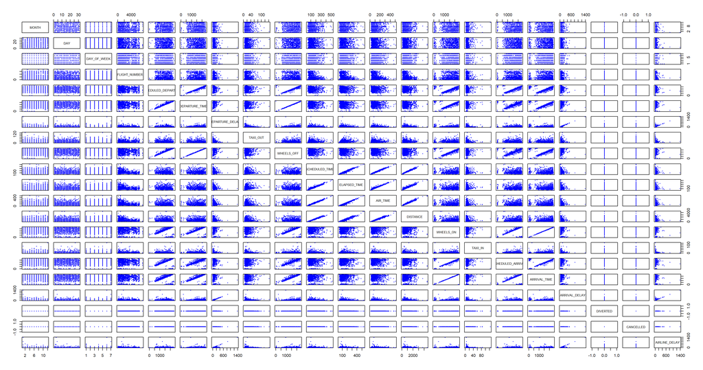

```r
flights_samples <- flights[sample(nrow(flights), 1000), ]  # Берём 1000 случайных строк
plot(Filter(is.numeric, flights_samples)[ ,-1], pch=20, col="blue", cex=0.5)
```

### Korrelatsioon DISTANCE ja AIRLINE_DELAY vahel

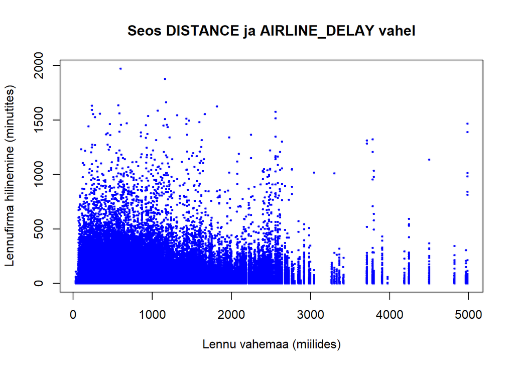

```r
plot(flights$DISTANCE, flights$AIRLINE_DELAY,
     main = "Seos DISTANCE ja AIRLINE_DELAY vahel",
     xlab = "Lennu vahemaa (miilides)",
     ylab = "Lennufirma hilinemine (minutites)",
     col = "blue", pch = 20, cex = 0.5)
```

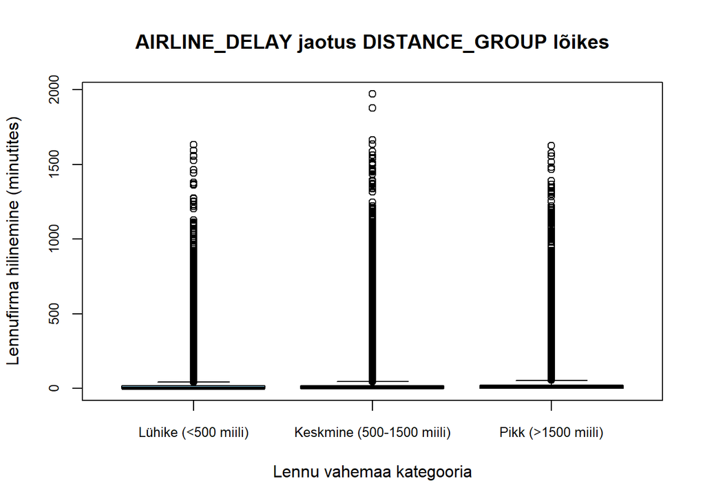

```r
flights$DISTANCE_GROUP <- cut(flights$DISTANCE, breaks = c(0, 500, 1500, Inf), labels = c("Lühike (<500 miili)", "Keskmine (500-1500 miili)", "Pikk (>1500 miili)"))


boxplot(AIRLINE_DELAY ~ DISTANCE_GROUP, data = flights, main = "AIRLINE_DELAY jaotus DISTANCE_GROUP lõikes", ylab = "Lennufirma hilinemine (minutites)", xlab = "Lennu vahemaa kategooria", col = "skyblue", cex.axis = 0.8)
```

Graafiku põhjal ei saa öelda, et pikemad lennud põhjustavad oluliselt rohkem hilinemisi. Enamik suuri hilinemisi toimub lühikestel ja keskmise pikkusega lendudel, mis võib viidata sellele, et hilinemiste põhjused ei ole seotud vahemaaga, vaid pigem lennujaamade töökorralduse, ühenduslennuga ootamise või ilmastikutingimustega.

## Arvuliste tunnuste analüüs

### Pidev tunnus

Visualiseerime tunnuse väärtuste jaotuse hist() funktsiooni abil:

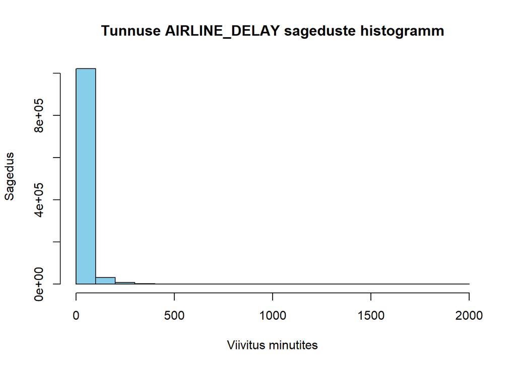

```r
h <- hist(flights$AIRLINE_DELAY, col = "skyblue", main = "Tunnuse AIRLINE_DELAY sageduste histogramm", xlab = "Viivitus minutites", ylab = "Sagedus")
```

Tunnuse AIRLINE_DELAY suhteliste sageduste histogramm ja karpdiagramm:

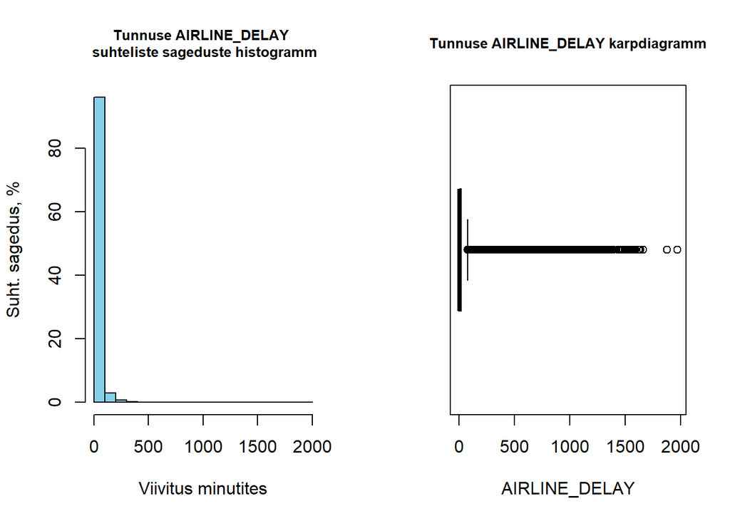

```r
par(mfrow=c(1,2))
h$counts <- h$counts / sum(h$counts) * 100
plot(h, col = "skyblue", main = "Tunnuse AIRLINE_DELAY \n suhteliste sageduste histogramm", xlab = "Viivitus minutites", ylab = "Suht. sagedus, %", cex.main = 0.8)


b <- boxplot(flights$AIRLINE_DELAY, col = "skyblue", horizontal = 1, main = "Tunnuse AIRLINE_DELAY karpdiagramm", xlab = "AIRLINE_DELAY", cex.main = 0.8, range = 3)
```

Tunnuse AIRLINE_DELAY jaotus on parempoolse asümmeetriaga, mis tähendab, et viivitused on sageli jaotunud väikeste väärtuste ümber, kuid samas esinevad ka mõned suuremad viivitused, mis moodustavad erandeid. Seda on võimalik täheldada nii histogrammist kui ka karpdiagrammist.

Histogrammist on näha, et enamiku viivituste väärtused on madalamad, kuid on ka mõned erandid (kõrgemad viivitused), mis tõstavad jaotust paremale poole. Karpdiagramm näitab, et AIRLINE_DELAY tunnuses esineb mõningaid äärmuslikke väärtusi, kuna on olemas suurte viivitustega “väljujaid” (outliers), mis asuvad kõrgemal kui tavapärased väärtused.

Kokkuvõttes, AIRLINE_DELAY ei ole sümmeetriline ja sisaldab mõningaid äärmuslikke väärtusi, mis tuleb arvesse võtta analüüsi edasistes etappides.

### Erindite analüüs.

```r
indices <- head(sort(b$out),10)
```

Objektid, mis esinevad erinditena:

```r
indices <- head(which(flights$AIRLINE_DELAY %in% b$out), 10)
```

Info erindite kohta:

```r
library(DT)
datatable(head(flights[which(flights$AIRLINE_DELAY %in% b$out), ], 10), options = list(scrollX = TRUE, pageLength = 5, searching = FALSE, scroller = TRUE, scrollY = 200))
```

|  | YEAR | MONTH | DAY | DAY_OF_WEEK | AIRLINE | FLIGHT_NUMBER | TAIL_NUMBER | ORIGIN_AIRPORT | DESTINATION_AIRPORT | SCHEDULED_DEPARTURE | DEPARTURE_TIME | DEPARTURE_DELAY | TAXI_OUT | WHEELS_OFF | SCHEDULED_TIME | ELAPSED_TIME | AIR_TIME | DISTANCE | WHEELS_ON | TAXI_IN | SCHEDULED_ARRIVAL | ARRIVAL_TIME | ARRIVAL_DELAY | DIVERTED | CANCELLED | CANCELLATION_REASON | AIRLINE_DELAY | DISTANCE_GROUP |
| --- | --- | --- | --- | --- | --- | --- | --- | --- | --- | --- | --- | --- | --- | --- | --- | --- | --- | --- | --- | --- | --- | --- | --- | --- | --- | --- | --- | --- |
| 5 | 2015 | 1 | 1 | 4 | B6 | 2134 | N307JB | SJU | MCO | 400 | 535 | 95 | 9 | 544 | 185 | 175 | 163 | 1189 | 727 | 3 | 605 | 730 | 85 | 0 | 0 | Unknown | 85 | Keskmine (500-1500 miili) |
| 61 | 2015 | 1 | 1 | 4 | WN | 1966 | N466WN | CMH | ATL | 615 | 831 | 136 | 13 | 844 | 110 | 90 | 65 | 447 | 949 | 12 | 805 | 1001 | 116 | 0 | 0 | Unknown | 116 | Lühike (&lt;500 miili) |
| 64 | 2015 | 1 | 1 | 4 | EV | 2522 | N879AS | LAW | DFW | 615 | 1219 | 364 | 27 | 1246 | 55 | 67 | 30 | 140 | 1316 | 10 | 710 | 1326 | 376 | 0 | 0 | Unknown | 364 | Lühike (&lt;500 miili) |
| 66 | 2015 | 1 | 1 | 4 | MQ | 3432 | N546MQ | DCA | JFK | 615 | 859 | 164 | 10 | 909 | 63 | 60 | 41 | 213 | 950 | 9 | 718 | 959 | 161 | 0 | 0 | Unknown | 115 | Lühike (&lt;500 miili) |
| 71 | 2015 | 1 | 1 | 4 | AA | 1207 | N3DPAA | PHL | DFW | 625 | 909 | 164 | 21 | 930 | 235 | 238 | 206 | 1303 | 1156 | 11 | 920 | 1207 | 167 | 0 | 0 | Unknown | 164 | Keskmine (500-1500 miili) |
| 99 | 2015 | 1 | 1 | 4 | AA | 1273 | N023AA | MIA | IAH | 700 | 823 | 83 | 18 | 841 | 178 | 207 | 155 | 964 | 1016 | 34 | 858 | 1050 | 112 | 0 | 0 | Unknown | 83 | Keskmine (500-1500 miili) |
| 103 | 2015 | 1 | 1 | 4 | B6 | 1109 | N651JB | BOS | JAX | 700 | 913 | 133 | 27 | 940 | 188 | 186 | 156 | 1010 | 1216 | 3 | 1008 | 1219 | 131 | 0 | 0 | Unknown | 131 | Keskmine (500-1500 miili) |
| 105 | 2015 | 1 | 1 | 4 | AA | 2393 | N3APAA | JFK | MCO | 700 | 857 | 117 | 39 | 936 | 185 | 185 | 141 | 944 | 1157 | 5 | 1005 | 1202 | 117 | 0 | 0 | Unknown | 117 | Keskmine (500-1500 miili) |
| 132 | 2015 | 1 | 1 | 4 | EV | 5242 | N707EV | CLE | LGA | 715 | 959 | 164 | 12 | 1011 | 106 | 75 | 59 | 419 | 1110 | 4 | 901 | 1114 | 133 | 0 | 0 | Unknown | 133 | Lühike (&lt;500 miili) |
| 149 | 2015 | 1 | 1 | 4 | AA | 1499 | N854AA | DFW | LAS | 730 | 1055 | 205 | 27 | 1122 | 175 | 180 | 148 | 1055 | 1150 | 5 | 825 | 1155 | 210 | 0 | 0 | Unknown | 205 | Keskmine (500-1500 miili) |

```r
intervallid <- cut(flights$AIRLINE_DELAY, seq(0, max(flights$AIRLINE_DELAY, na.rm = TRUE), by = 1), include.lowest = TRUE)
sagedus <- table(intervallid)
suht.sagedus <- prop.table(table(intervallid)) * 100
sagedustabel <- cbind(rownames(sagedus), sagedus, round(suht.sagedus, 2), round(cumsum(suht.sagedus), 2))

sagedustabel <- data.frame(sagedustabel, row.names = NULL)
sagedustabel <- rbind(sagedustabel, c("Total", sum(sagedus), sum(suht.sagedus), ""))
names(sagedustabel) <- c("AIRLINE_DELAY", "sagedus", "suht.sagedus,%", "kum.suht.sagedus,%")
sagedustabel_filtered <- subset(sagedustabel, as.numeric(as.character(sagedus)) > 10)
sagedustabel_filtered_top5 <- head(sagedustabel_filtered, 10)


library(knitr)
library(kableExtra)

kable_styling(kable(sagedustabel_filtered_top5, align = c('l', 'r', 'r', 'r')), bootstrap_options = c("striped", "hover"), full_width = 0, position = "left")
```

| AIRLINE_DELAY | sagedus | suht.sagedus,% | kum.suht.sagedus,% |
| --- | --- | --- | --- |
| [0,1] | 514736 | 48.4 | 48.4 |
| (1,2] | 21211 | 1.99 | 50.4 |
| (2,3] | 20656 | 1.94 | 52.34 |
| (3,4] | 20184 | 1.9 | 54.24 |
| (4,5] | 19772 | 1.86 | 56.1 |
| (5,6] | 20107 | 1.89 | 57.99 |
| (6,7] | 18646 | 1.75 | 59.74 |
| (7,8] | 17494 | 1.65 | 61.39 |
| (8,9] | 16368 | 1.54 | 62.93 |
| (9,10] | 15570 | 1.46 | 64.39 |

```r
library(FSA)
arvkar <- Summarize(flights$AIRLINE_DELAY, digits = 2)
kable_styling(kable(t(arvkar)))
```

| n | mean | sd | min | Q1 | median | Q3 | max | percZero |
| --- | --- | --- | --- | --- | --- | --- | --- | --- |
| 1063439 | 18.97 | 48.16 | 0 | 0 | 2 | 19 | 1971 | 46.4 |

```r
Factors <- names(flights)[sapply(flights, function(col) is.factor(col) && nlevels(col) <= 20)]
```

```r
library(GGally)
```

```r
plot <- ggpairs(flights_samples[, c("AIRLINE_DELAY", "AIRLINE")],lower = 'blank',upper = list(continuous = wrap('points', color = 'blue'),combo = wrap('box', fill = 'blue', outlier.color = 'blue')),diag = list(continuous = wrap('barDiag', fill = 'blue')),progress = FALSE,axisLabels = "none")
```

## Sihttunnuse seos mittearvuliste tunnustega

Tulemusena saame hajuvusdiagrammide maatriksi, mis kuvab seoseid tunnuste “AIRLINE_DELAY” ja “AIRLINE” vahel. Maatriksis kasutatakse kastdiagramme ja punktdiagramme, et visualiseerida viivituste ja lennufirmade vahelisi erinevusi. Näeme, kuidas erinevate lennufirmade puhul jaotuvad hilinemised – näiteks millistel on rohkem äärmuslikke väärtusi. See aitab tuvastada, millised lennufirmad kalduvad sagedamini hilinema.

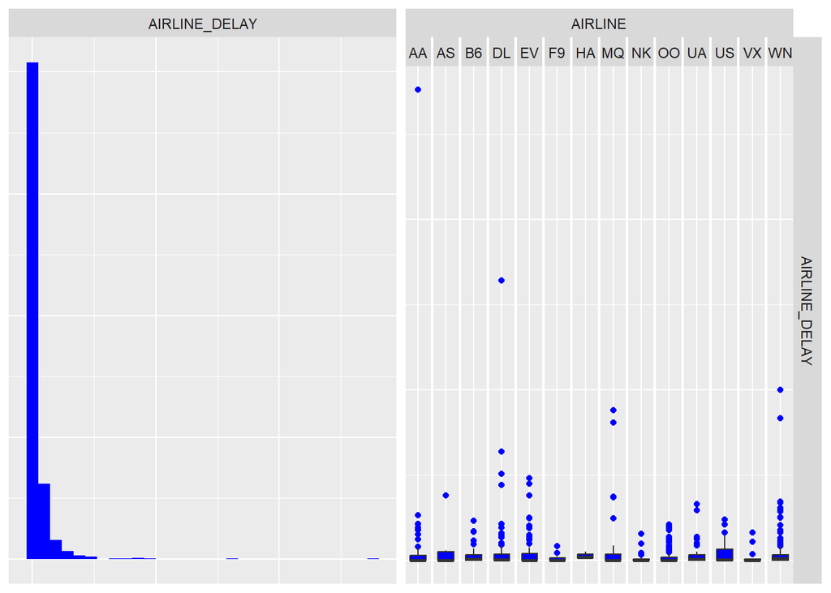

```r
plot$nrow <- 1
plot$yAxisLabels <- plot$yAxisLabels[1]
plot
```

## Mittearvulise tunnuse analüüs

```r
flights$AIRLINE <- factor(flights$AIRLINE, levels = c("WN", "AA", "DL", "EV", "UA", "AS", "B6", "OO", "NK", "F9", "HA", "MQ", "G4", "YV"))
```

Visualiseerime tunnuse väärtuste jaotuse tulpdiagrammil:

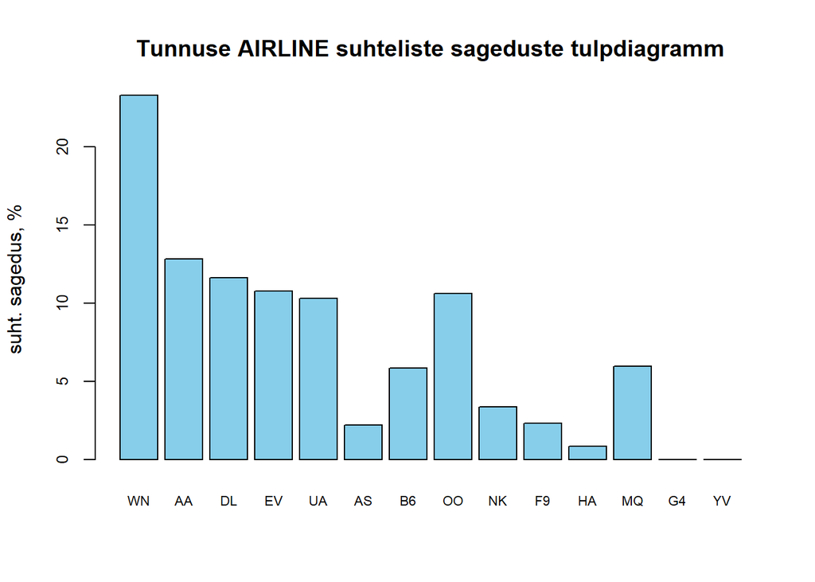

```r
barplot(prop.table(table(flights$AIRLINE)) * 100, col = "skyblue", cex.names = 0.7, cex.axis = 0.8,
        main = "Tunnuse AIRLINE suhteliste sageduste tulpdiagramm", ylab = "suht. sagedus, %")
```

```r
sagedus <- table(flights$AIRLINE)
suht.sagedus <- round(prop.table(table(flights$AIRLINE)) * 100, 2)
sagedustabel <- cbind(rownames(sagedus), sagedus, suht.sagedus)
sagedustabel <- data.frame(sagedustabel, row.names = NULL)
sagedustabel <- rbind(sagedustabel, c("Total", sum(sagedus), sum(suht.sagedus)))
names(sagedustabel) <- c("AIRLINE", "sagedus", "suht.sagedus,%")


library(knitr)
library(kableExtra)

kable_styling(kable(sagedustabel, align = c('l', 'r', 'r')), bootstrap_options = c("striped", "hover"),
              full_width = 0, position = "left")
```

| AIRLINE | sagedus | suht.sagedus,% |
| --- | --- | --- |
| WN | 236626 | 23.31 |
| AA | 130279 | 12.83 |
| DL | 118023 | 11.63 |
| EV | 109184 | 10.76 |
| UA | 104722 | 10.32 |
| AS | 22352 | 2.2 |
| B6 | 59175 | 5.83 |
| OO | 107795 | 10.62 |
| NK | 34221 | 3.37 |
| F9 | 23570 | 2.32 |
| HA | 8618 | 0.85 |
| MQ | 60547 | 5.96 |
| G4 | 0 | 0 |
| YV | 0 | 0 |
| Total | 1015112 | 100 |

Southwest Airlines (WN) domineerib selles valimis, mis võib viidata sellele, et neil on suurem lendude arv või lai lennugraafik.

American Airlines ja Delta Air Lines on samuti tugevalt esindatud, kuid nende osakaal on väiksem võrreldes WN-iga.

## Sihttunnuse sõltuvus kategoriaalsest tunnusest (Airline Delay - Airline)

Uurime sihttunnuse AIRLINE_DELAY sõltuvust kategoriaalsest tunnusest AIRLINE. Esitame sihttunnuse AIRLINE_DELAY karpdiagrammid kategoriaalse tunnuse väärtuste rühmades:

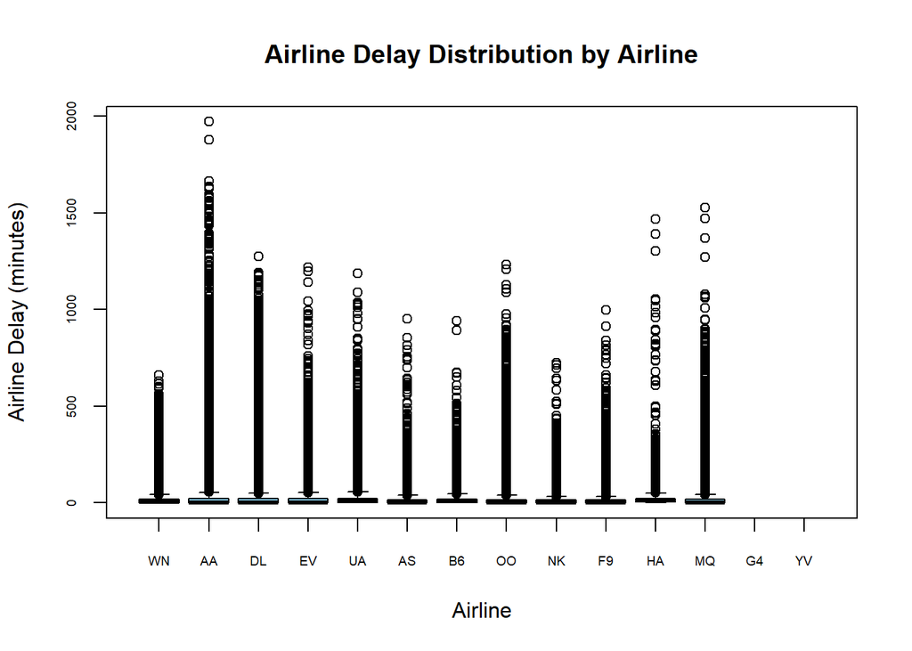

```r
boxplot(AIRLINE_DELAY ~ AIRLINE, data = flights,
        main = "Airline Delay Distribution by Airline",
        ylab = "Airline Delay (minutes)",
        xlab = "Airline",
        col = "skyblue", cex.axis = 0.6)
```

Järeldus: Boxploti põhjal on erinevate lennufirmade hilinemiste jaotus erinev. Kõige rohkem hilinemisi esineb lennufirma “AA” (American Airlines) puhul, kus esinevad suuremad hilinemised võrreldes teiste lennufirmadega. Kõikide lennufirmade hilinemisjaotused on parempoolsed asümmeetrilised, mis tähendab, et hilinemised on suunatud suuremate väärtuste poole, kuid samas on ka mitmed väikesed hilinemised.

Enamus hilinemisi on vahemikus 0-30 minutit, kuid on ka erandeid, kus hilinemised ulatuvad 100 minuti ja rohkemini. Lennufirmadel on suur erinevus hilinemiste sageduses, kus mõned lennufirmad näitavad selgelt suuremat hilinemist võrreldes teistega.

Grafikut vaadates on selge, et mõned lennufirmad suudavad hoida oma hilinemised madalamal tasemel, samas kui teised kipuvad esitlema rohkem äärmuslikke hilinemisi.

## Sihttunnuse sõltuvus kategoriaalsest tunnusest (Airline Delay - Origin Airport)

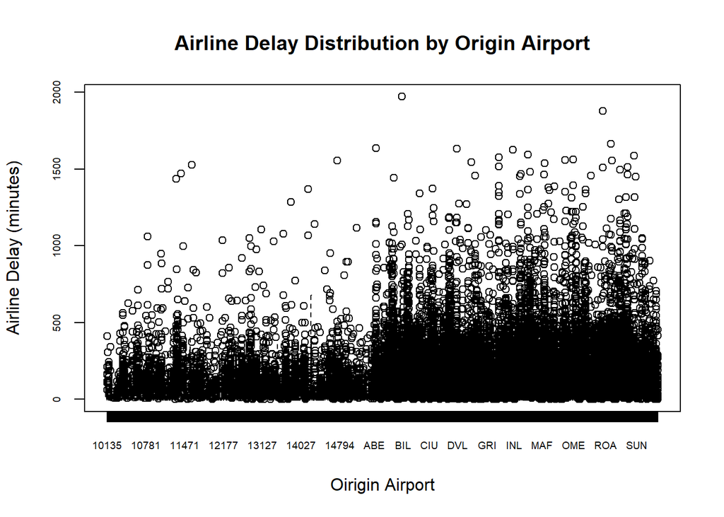

```r
boxplot(AIRLINE_DELAY ~ ORIGIN_AIRPORT, data = flights,
        main = "Airline Delay Distribution by Origin Airport",
        ylab = "Airline Delay (minutes)",
        xlab = "Oirigin Airport",
        col = "skyblue", cex.axis = 0.6)
```

Järeldus: Graafikult, mis kujutab lennuhilinemisi sõltuvalt lähtelennujaamast (ORIGIN_AIRPORT), on näha, et mõned lennujaamad – näiteks ISN, GRB ja MAF – paistavad silma sellega, et neist toimub küll vähe lende, kuid suur osa neist hilineb tugevalt.

Need lennujaamad on graafikul eristatavad selle järgi, et neil on vähe punkte X-teljel, aga need punktid on kõrgel Y-teljel, mis tähendab, et hilinemised ulatuvad sageli üle 500 või isegi 1000 minuti.

See viitab sellele, et kuigi tegemist pole suurte jaamadega, tekivad seal regulaarselt suured hilinemised. Põhjuseks võivad olla ilmastikuolud, organisatoorsed probleemid või maandumisraja piiratud kasutus.

## Sihttunnuse sõltuvus kategoriaalsest tunnusest (Airline Delay - Tail Number)

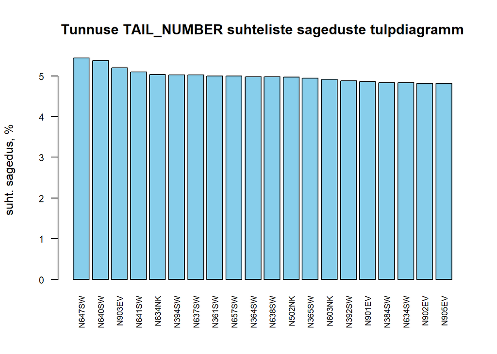

```r
tail_number_freq <- table(flights$TAIL_NUMBER)
top_n <- 20
top_tail_numbers <-tail_number_freq[order(-tail_number_freq)][1:top_n]
barplot(prop.table(top_tail_numbers) * 100,
        col = "skyblue",
        cex.names = 0.7,
        cex.axis = 0.8,
        main = "Tunnuse TAIL_NUMBER suhteliste sageduste tulpdiagramm",
        ylab = "suht. sagedus, %",
        las = 2)
```

Tulpdiagrammi tulemusel saame ülevaate, millised saba numbrid on andmestikus kõige sagedamini esindatud. Näeme, et saba numbrite suhteline sagedus andmestikus on enam-vähem ühtlane, mis viitab sellele, et erinevate saba numbrite esindatus on tasakaalus ning iga saba numbrite esindatus ei ole üksteisest oluliselt erinev.

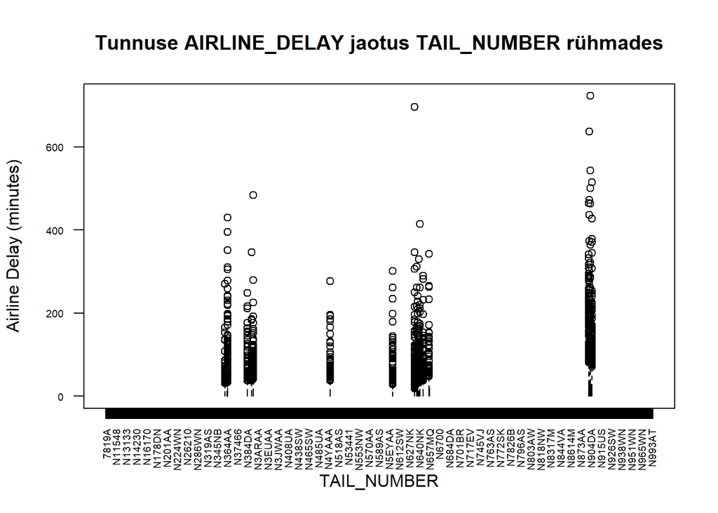

```r
tail_number_freq <- table(flights$TAIL_NUMBER)
top_n <- 20
top_tail_numbers <- names(tail_number_freq[order(-tail_number_freq)][1:top_n])
flights_top <- flights[flights$TAIL_NUMBER %in% top_tail_numbers, ]
boxplot(AIRLINE_DELAY ~ TAIL_NUMBER, data = flights_top,
        main = "Tunnuse AIRLINE_DELAY jaotus TAIL_NUMBER rühmades",
        ylab = "Airline Delay (minutes)",
        xlab = "TAIL_NUMBER",
        col = "skyblue", cex.axis = 0.6, las = 2)
```

# 2. osa

```r
flights = read.csv("flights_cleaned.csv", dec = ".",stringsAsFactors = TRUE)
```

```r
summary(flights$AIRLINE_DELAY)
```

```
##    Min. 1st Qu.  Median    Mean 3rd Qu.    Max.
##    0.00    0.00    2.00   18.97   19.00 1971.00
```

## 1. Uurige oma sihttunnuse jaotuse vastavust normaaljaotusele.

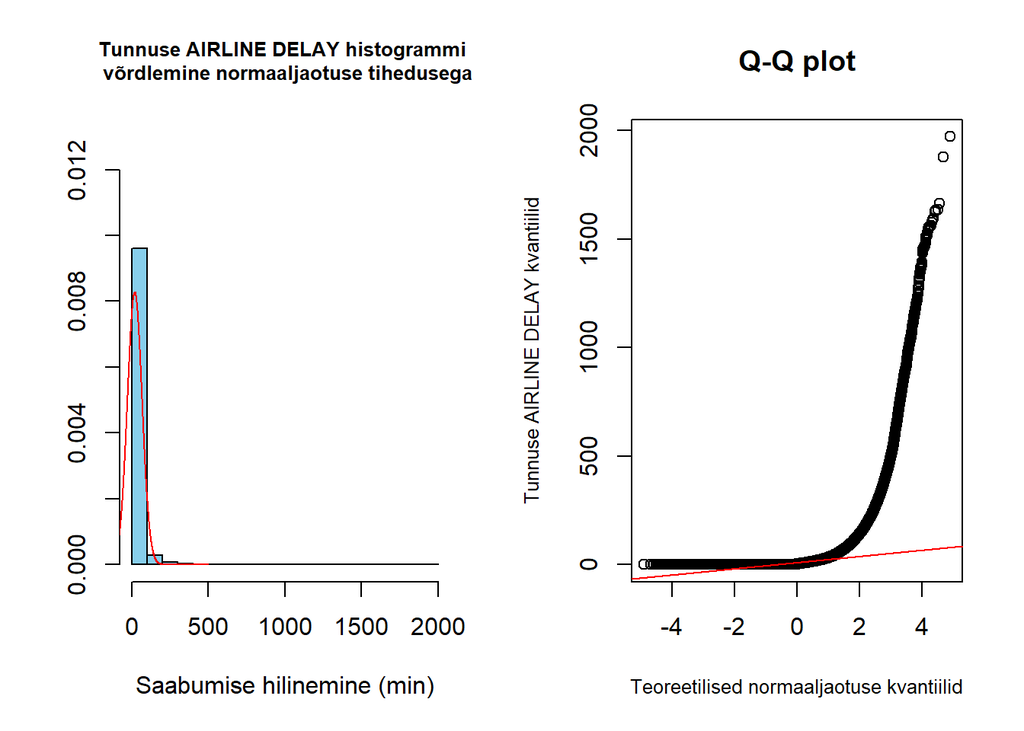

```r
par(mfrow=c(1,2))
hist(flights$AIRLINE_DELAY,freq = FALSE, main="Tunnuse AIRLINE DELAY histogrammi \n võrdlemine normaaljaotuse tihedusega", ylab = NULL,xlab="Saabumise hilinemine (min)", cex.main=0.8, ylim = c(0, 0.013), col = "skyblue")
lines(seq(-100,500,by=1),dnorm(seq(-100,500,by=1),mean(flights$AIRLINE_DELAY),sd(flights$AIRLINE_DELAY)), col="red")
qqnorm(flights$AIRLINE_DELAY,main="Q-Q plot",xlab="Teoreetilised normaaljaotuse kvantiilid", ylab="Tunnuse AIRLINE DELAY kvantiilid", cex.lab=0.8)
qqline(flights$AIRLINE_DELAY, col="red")
```

Järeldus: Tunnuse Airline Delay jaotus on parempoolse asümmeetriaga ning selle parempoolne saba erineb oluliselt normaaljaotusest. Histogramm näitab, et enamik hilinemise väärtusi on koondunud nulli lähedale, kuid esineb pikk parempoolne saba – harvad, kuid väga suured hilinemised. Punane joon tähistab normaaljaotuse tihedust, mis ei ühti tegeliku jaotuse kujuga, kinnitades jaotuse mittevastavust normaalsusele. Siiski, kuna andmestik sisaldab 1063439 objekti, saame kasutada usaldusintervallide leidmiseks parameetrilisi valemeid ja parameetrilisi hüpoteeside teste.

## 2. Leidke 95% usaldusintervall sihttunnuse keskväärtusele. Leidke 95% usaldusintervallid sihttunnuse keskväärtusele ka eraldi kõige rohkem mõjuva kategoriaalse tunnuse rühmades. Kirjutage välja kõik leitud usaldusintervallid.

Sihttunnuse arvkarasteristikud:

```r
options(scipen = 999); library(FSA); print(round(Summarize(flights$AIRLINE_DELAY), 2))
```

```
##          n       mean         sd        min         Q1     median         Q3
## 1063439.00      18.97      48.16       0.00       0.00       2.00      19.00
##        max   percZero
##    1971.00      46.40
```

n – vaatlusandmete koguarv (lende kokku: 1 063 439) mean – keskmine hilinemine (18,97 minutit) sd – standardhälve ehk hajuvus keskmise ümber (48,16 minutit) min – minimaalne hilinemine (0 minutit) Q1 – esimene kvartiil: 25% lendudest hilinesid 0 minutit või vähem median – mediaan: 50% lendudest hilinesid 2 minutit või vähem Q3 – kolmas kvartiil: 75% lendudest hilinesid 19 minutit või vähem max – maksimaalne hilinemine (1971 minutit) percZero – hilinemiseta lendude osakaal (46,4%)

Leian 95% usaldusintervall sihttunnuse Y=AIRLINE_DELAY keskväärtusele. Kasutan paketi Rmisc funktsiooni CI() :

```r
library(Rmisc)
CI(flights$AIRLINE_DELAY)
```

```
##    upper     mean    lower
## 19.06108 18.96955 18.87801
```

Vastus: 95% usaldusintervall tunnuse AIRLINE_DELAY keskväärtusele on (18.88; 19.06). See on intervall, kuhu tunnuse AIRLINE_DELAY teoreetiline keskmine kuulub tõenäosusega 95%.

Leian 95% usaldusintervallid sihttunnuse AIRLINE_DELAY keskväärtusele eraldi kategoriaalse tunnuse AIRLINE rühmades. Kasutan paketi rcompanion funktsiooni groupwiseMean():

```r
library(rcompanion)
flights$AIRLINE <- factor(flights$AIRLINE, levels = levels(flights$AIRLINE))
ryhmad = groupwiseMean(AIRLINE_DELAY~AIRLINE, data = flights, conf = 0.95, digits = 5)
print(ryhmad)
```

```
##    AIRLINE      n   Mean Conf.level Trad.lower Trad.upper
## 1       AA 130279 21.139       0.95     20.805     21.474
## 2       AS  22352 15.543       0.95     15.005     16.082
## 3       B6  59175 18.151       0.95     17.856     18.445
## 4       DL 118023 22.941       0.95     22.580     23.302
## 5       EV 109184 21.651       0.95     21.354     21.949
## 6       F9  23570 14.720       0.95     14.169     15.271
## 7       HA   8618 22.792       0.95     21.535     24.049
## 8       MQ  60547 17.425       0.95     17.026     17.824
## 9       NK  34221 13.767       0.95     13.411     14.123
## 10      OO 107795 18.959       0.95     18.642     19.276
## 11      UA 104722 21.145       0.95     20.883     21.406
## 12      US  36549 17.410       0.95     17.035     17.785
## 13      VX  11778 11.098       0.95     10.539     11.656
## 14      WN 236626 16.192       0.95     16.054     16.330
```

Vastus: 95% usaldusintervallid tunnuse AIRLINE_DELAY keskväärtusele tunnuse AIRLINE rühmades on:

rühmas AIRLINE = AA (American Airlines): (20.805; 21.474) rühmas AIRLINE = AS (Alaska Airlines): (15.005; 16.082) rühmas AIRLINE = B6 (JetBlue Airways): (17.856; 18.445) rühmas AIRLINE = DL (Delta Air Lines): (22.580; 23.302) rühmas AIRLINE = EV (ExpressJet Airlines): (21.354; 21.949) rühmas AIRLINE = F9 (Frontier Airlines): (14.169; 15.271) rühmas AIRLINE = HA (Hawaiian Airlines): (21.535; 24.049) rühmas AIRLINE = MQ (Envoy Air / American Eagle): (17.026; 17.824) rühmas AIRLINE = NK (Spirit Airlines): (13.411; 14.123) rühmas AIRLINE = OO (SkyWest Airlines): (18.642; 19.276) rühmas AIRLINE = UA (United Airlines): (20.883; 21.406) rühmas AIRLINE = US (US Airways): (17.035; 17.785) rühmas AIRLINE = VX (Virgin America): (10.539; 11.656) rühmas AIRLINE = WN (Southwest Airlines): (16.054; 16.330)

Nüüd iga rühma AIRLINE korral on leitud intervall, kuhu tunnuse AIRLINE_DELAY vastava rühma teoreetiline keskmine kuulub tõenäosusega 95%.

## 3. Visualiseerige kategoriaalse tunnuse rühmades leitud keskväärtuse usaldusintervallid Cleveland plot diagrammil. Kommenteerige saadud tulemused.

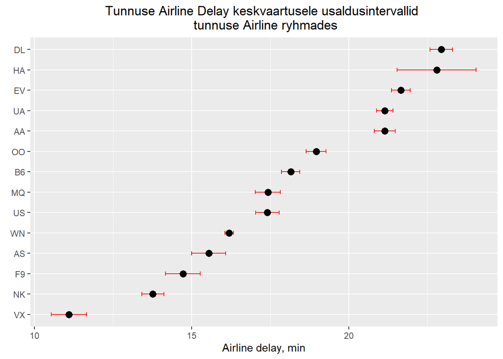

```r
library(ggplot2)
ggplot(ryhmad,aes(x = ryhmad[,3] , y = reorder(AIRLINE,
                                               ryhmad[,3]))) +
  geom_errorbarh(aes(xmin = ryhmad[,5], xmax = ryhmad[,6]), height = 0.2, col="red")+geom_point(size = 3) +
  labs(y = element_blank(),x="Airline delay, min") +
  ggtitle("Tunnuse Airline Delay keskvaartusele usaldusintervallid \n tunnuse Airline ryhmades")+
  theme(plot.title=element_text(hjust = 0.5))
```

Järeldus: Intervallid näitavad, et kõige kõrgem hilinemise keskmine on lennufirmal DL (Delta Air Lines). Kõige väiksem keskmine hilinemine on lennufirmal VX (Virgin America), mille usaldusintervall ei kattu ühegi suurima hilinemisega rühma intervalliga, mis viitab sellele, et Virgin America lendudel oli keskmiselt väiksem hilinemine. Kui te ei soovi hilineda, siis valige Virgin America.

## Valige kategoriaalse tunnuse kaks rühma, milles punktides 2-3 leitud erinevus on kõige suurem. Võrrelge rühmade keskmised karpdagrammil ja arvuliselt (arvutage keskmised ja ka teised põhikarakteristikud rühmades). Sõnastage hüpoteesid, tehke läbi vajalik test, võtke vastu otsus. (Olulisuse nivoo 0.05).

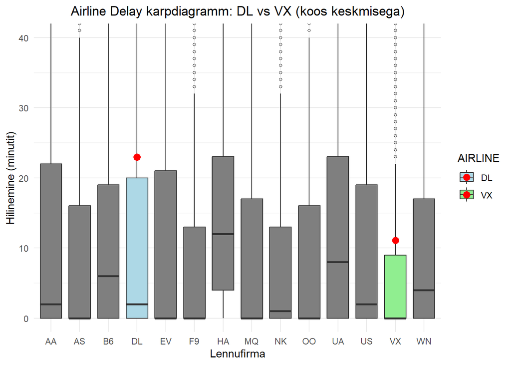

```r
library(ggplot2)

ggplot(flights, aes(x = AIRLINE, y = AIRLINE_DELAY, fill = AIRLINE)) +
  geom_boxplot(outlier.shape = 1, outlier.size = 1) +
  coord_cartesian(ylim = c(0, 40)) +
  geom_point(data = data.frame(AIRLINE = c("DL", "VX"),
                               AIRLINE_DELAY = c(22.941, 11.098)),
             aes(x = AIRLINE, y = AIRLINE_DELAY),
             color = "red", size = 3) +
  labs(title = "Airline Delay karpdiagramm: DL vs VX (koos keskmisega)",
       x = "Lennufirma",
       y = "Hilinemine (minutit)") +
  theme_minimal() +
  theme(plot.title = element_text(hjust = 0.5)) +
  scale_fill_manual(values = c("VX" = "lightgreen", "DL" = "lightblue"))
```

Karpdiagrammilt on näha, et lennufirmade DL ja VX puhul on punased punktid (keskmised) oluliselt kõrgemal kui mustad horisontaalsed jooned kastis (mediaanid). See viitab sellele, et tunnuse AIRLINE_DELAY jaotus on paremale kaldu (positiivne asümmeetria) — enamus lende hilineb vähe, kuid mõned üksikud lennud hilinevad väga palju (nt. üle 500 minuti), mis tõstab keskmist märkimisväärselt üles.

Valin kategoriaalse tunnuse Airline kaks rühma, milles sihtunnuse Airline_Delay erinevus on kõige suurem: DL (Delta Air Lines) ja VX (Virgin America).

SÕNASTAN HüPOTEESI: kontrollinn olulise nivool @=0.05 hüpoteesis, kas rühmas DL keskmine hilinimise aeg on kõrgem kui rühmas VX.

$$H_0: \mu_{\text{DL}} = \mu_{\text{VX}} \\
H_1: \mu_{\text{DL}} > \mu_{\text{VX}}$$
Eelsamm: dispersioonide erinevuse kontroll Enne t-testi tegemist on vaja teada, kas tunnuse dispersioonid rühmades on võrdsed (H0: σ1=σ2) või erinevad (H1: σ1≠σ2):

```r
var.test(flights$AIRLINE_DELAY[flights$AIRLINE=="DL"],flights$AIRLINE_DELAY[flights$AIRLINE=="VX"])
```

```
##
##  F test to compare two variances
##
## data:  flights$AIRLINE_DELAY[flights$AIRLINE == "DL"] and flights$AIRLINE_DELAY[flights$AIRLINE == "VX"]
## F = 4.1856, num df = 118022, denom df = 11777, p-value <
## 0.00000000000000022
## alternative hypothesis: true ratio of variances is not equal to 1
## 95 percent confidence interval:
##  4.07439 4.29862
## sample estimates:
## ratio of variances
##           4.185626
```

Testi tulemus: p-value = 0.00000000000000022 < 0.05 -> kehtib H1 ehk dispersioonid on erinevad, st et kasutame edasi t.test-i atribuudiga var.equal = FALSE.

```r
t.test(flights$AIRLINE_DELAY[flights$AIRLINE=="DL"],flights$AIRLINE_DELAY[flights$AIRLINE=="VX"],alternative = "greater",var.equal = FALSE)
```

```
##
##  Welch Two Sample t-test
##
## data:  flights$AIRLINE_DELAY[flights$AIRLINE == "DL"] and flights$AIRLINE_DELAY[flights$AIRLINE == "VX"]
## t = 34.914, df = 23265, p-value < 0.00000000000000022
## alternative hypothesis: true difference in means is greater than 0
## 95 percent confidence interval:
##  11.28524      Inf
## sample estimates:
## mean of x mean of y
##  22.94103  11.09781
```

Testi tulemus: p-value = 0.00000000000000022 < 0.05 -> lükkame H0 tagasi ning järeldame, et rühmas DL (Delta Air Lines) lennude hilinemise keskmine on statistiliselt oluliselt suurem kui rühmas VX (Virgin America).

Vastus: Kuna testi olulisustõenäosus p-value < 0.00000000000000022 on väiksem kui olulisuse nivoo α = 0.05, siis lükkame nullhüpoteesi tagasi. See tähendab, et rühmas DL (Delta Air Lines) lennude hilinemise keskmine on statistiliselt oluliselt suurem kui rühmas VX (Virgin America).

# 3. osa

## Hüpotees 1: Nädalapäeva mõju AIRLINE_DELAY (ANOVA)

**Hüpotees**: AIRLINE_DELAY keskmised erinevad statistiliselt oluliselt nädalapäeviti.

Sihttunnus (Y): AIRLINE_DELAY (saabumishilinemine, numbriline) Selgitav tunnus (X): DAY_OF_WEEK (nädalapäev, kategooriline, 7 taset)

See analüüs viiakse läbi ühesuunalise ANOVA (Analysis of Variance) abil.

### Sihttunnuse jaotuse vastavust normaaljaotusele

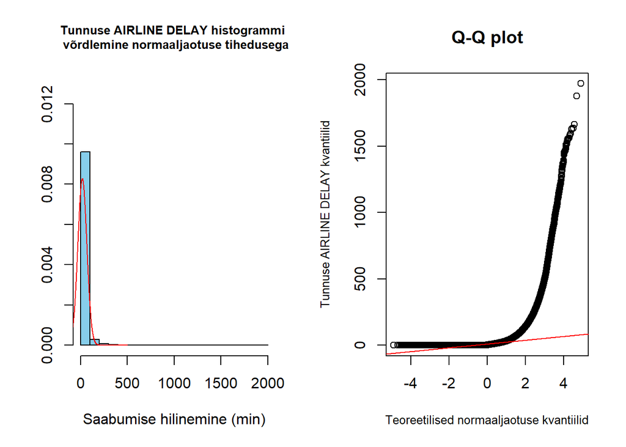

```r
par(mfrow=c(1,2))
hist(flights$AIRLINE_DELAY,freq = FALSE, main="Tunnuse AIRLINE DELAY histogrammi \n võrdlemine normaaljaotuse tihedusega", ylab = NULL,xlab="Saabumise hilinemine (min)", cex.main=0.8, ylim = c(0, 0.013), col = "skyblue")
lines(seq(-100,500,by=1),dnorm(seq(-100,500,by=1),mean(flights$AIRLINE_DELAY),sd(flights$AIRLINE_DELAY)), col="red")
qqnorm(flights$AIRLINE_DELAY,main="Q-Q plot",xlab="Teoreetilised normaaljaotuse kvantiilid", ylab="Tunnuse AIRLINE DELAY kvantiilid", cex.lab=0.8)
qqline(flights$AIRLINE_DELAY, col="red")
```

**Järeldus:** Tunnuse Airline Delay jaotus on parempoolse asümmeetriaga ning selle parempoolne saba erineb oluliselt normaaljaotusest. Histogramm näitab, et enamik hilinemise väärtusi on koondunud nulli lähedale, kuid esineb pikk parempoolne saba – harvad, kuid väga suured hilinemised. Punane joon tähistab normaaljaotuse tihedust, mis ei ühti tegeliku jaotuse kujuga, kinnitades jaotuse mittevastavust normaalsusele. Siiski, kuna andmestik sisaldab 1063439 objekti, saame kasutada usaldusintervallide leidmiseks parameetrilisi valemeid ja parameetrilisi hüpoteeside teste.

### Andmete ettevalmistamine analüüsiks

Enne analüüsi alustamist veendume, et nädalapäeva tunnus on korrektselt faktoriks teisendatud ja selle tasemetele on antud tähenduslikud nimed.

```r
flights$DAY_OF_WEEK <- factor(flights$DAY_OF_WEEK,
                              levels = 1:7,
                              labels = c("Esmaspäev", "Teisipäev", "Kolmapäev", "Neljapäev", "Reede", "Laupäev", "Pühapäev"))
```

### Kirjeldav statistika ja visualiseerimine

Andmete esmane uurimine kirjeldava statistika ja visualiseerimise abil annab hea ülevaate nädalapäevade lõikes esinevatest saabumishilinemiste mustritest.

Keskmiste ja teiste karakteristikute arvutamine nädalapäeviti

```r
library(FSA)
options(scipen = 999)
delay_by_day <- Summarize(AIRLINE_DELAY ~ DAY_OF_WEEK, data = flights)
```

### Karpplodid nädalapäeviti

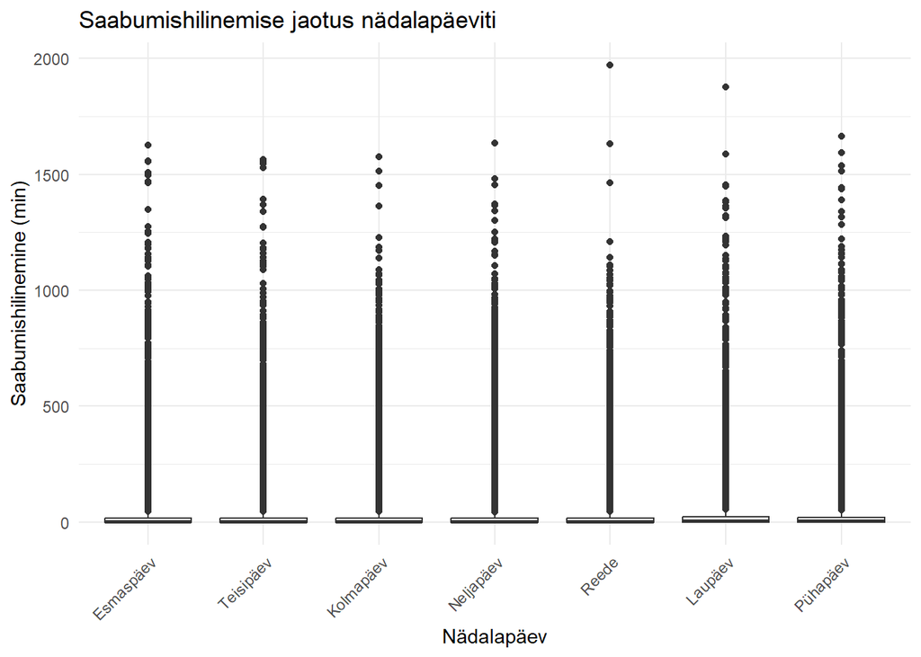

```r
library(ggplot2)
ggplot(flights, aes(x = DAY_OF_WEEK, y = AIRLINE_DELAY)) +
  geom_boxplot() +
  labs(title = "Saabumishilinemise jaotus nädalapäeviti",
       x = "Nädalapäev",
       y = "Saabumishilinemine (min)") +
  theme_minimal() +
  theme(axis.text.x = element_text(angle = 45, hjust = 1))
```

### ANOVA eelduste kontroll

Enne ANOVA testi tegemist kontrollitakse dispersioonide homogeensust Levene’i testiga

```r
library(car)
leveneTest(AIRLINE_DELAY ~ DAY_OF_WEEK, data = flights)
```

```
## Levene's Test for Homogeneity of Variance (center = median)
##            Df F value                Pr(>F)
## group       6  93.094 < 0.00000000000000022 ***
##       1063432
## ---
## Signif. codes:  0 '***' 0.001 '**' 0.01 '*' 0.05 '.' 0.1 ' ' 1
```

**Järeldus:** Levene’i testi p-väärtus (Pr(>F)) on < 0.00000000000000022, mis on oluliselt väiksem kui tavapäraselt aktsepteeritud olulisuse tase 0.05. See näitab, et gruppide (nädalapäevade) dispersioonid on statistiliselt oluliselt erinevad (ehk dispersioonide homogeensuse eeldus on rikutud).

### Hüpoteesi testimine (ANOVA)

Viime läbi ühefaktorilise ANOVA, et kontrollida, kas nädalapäevade lõikes esineb statistiliselt olulisi erinevusi keskmises saabumishilinemises.

```r
anova_result_day <- aov(AIRLINE_DELAY ~ DAY_OF_WEEK, data = flights)
summary(anova_result_day)
```

```
##                  Df     Sum Sq Mean Sq F value              Pr(>F)
## DAY_OF_WEEK       6    1485479  247580   106.8 <0.0000000000000002 ***
## Residuals   1063432 2465205488    2318
## ---
## Signif. codes:  0 '***' 0.001 '**' 0.01 '*' 0.05 '.' 0.1 ' ' 1
```

**Järeldus:** ANOVA testi tulemustest näeme, et p-väärtus (Pr(>F) veerus) tunnuse DAY_OF_WEEK jaoks on < 0.0000000000000002. See väärtus on oluliselt väiksem kui 0.05, mis on üldiselt aktsepteeritud olulisuse tase. Seetõttu lükatakse nullhüpotees tagasi. See annab statistiliselt olulise tõendi, et vähemalt ühe nädalapäeva keskmine lennufirma põhjustatud hilinemine erineb teiste päevade keskmistest. Teisisõnu, nädalapäev mõjutab statistiliselt oluliselt lennufirma põhjustatud lendude hilinemisi.

### Post-hoc test (Tukey HSD)

Kuna ANOVA tulemus oli statistiliselt oluline, teostame Tukey HSD post-hoc testi, et selgitada välja, milliste nädalapäevade paaride vahel need erinevused esinevad.

```r
TukeyHSD(anova_result_day)
```

```
##   Tukey multiple comparisons of means
##     95% family-wise confidence level
##
## Fit: aov(formula = AIRLINE_DELAY ~ DAY_OF_WEEK, data = flights)
##
## $DAY_OF_WEEK
##                            diff        lwr         upr     p adj
## Teisipäev-Esmaspäev -0.32369982 -0.8281637  0.18076410 0.4856917
## Kolmapäev-Esmaspäev -0.70252902 -1.2049064 -0.20015161 0.0007402
## Neljapäev-Esmaspäev -1.42556776 -1.9139962 -0.93713933 0.0000000
## Reede-Esmaspäev     -0.73624060 -1.2306972 -0.24178399 0.0002289
## Laupäev-Esmaspäev    2.67740859  2.1261714  3.22864576 0.0000000
## Pühapäev-Esmaspäev   1.07542294  0.5671568  1.58368909 0.0000000
## Kolmapäev-Teisipäev -0.37882920 -0.8930999  0.13544153 0.3108933
## Neljapäev-Teisipäev -1.10186794 -1.6025212 -0.60121471 0.0000000
## Reede-Teisipäev     -0.41254078 -0.9190767  0.09399516 0.1978558
## Laupäev-Teisipäev    3.00110841  2.4390108  3.56320604 0.0000000
## Pühapäev-Teisipäev   1.39912276  0.8790979  1.91914758 0.0000000
## Neljapäev-Kolmapäev -0.72303875 -1.2215895 -0.22448797 0.0003815
## Reede-Kolmapäev     -0.03371158 -0.5381696  0.47074642 0.9999951
## Laupäev-Kolmapäev    3.37993761  2.8197118  3.94016341 0.0000000
## Pühapäev-Kolmapäev   1.77795195  1.2599510  2.29595294 0.0000000
## Reede-Neljapäev      0.68932716  0.1987590  1.17989536 0.0006799
## Laupäev-Neljapäev    4.10297635  3.5552244  4.65072834 0.0000000
## Pühapäev-Neljapäev   2.50099070  1.9965065  3.00547490 0.0000000
## Laupäev-Reede        3.41364919  2.8605152  3.96678320 0.0000000
## Pühapäev-Reede       1.81166354  1.3013408  2.32198628 0.0000000
## Pühapäev-Laupäev    -1.60198565 -2.1674981 -1.03647316 0.0000000
```

**Järeldus:** Tukey HSD testi tulemused esitavad paarikaupa võrdlused iga nädalapäeva vahel lennufirma põhjustatud hilinemiste osas.

diff veerg näitab keskmiste lennufirma põhjustatud hilinemiste erinevust päevade vahel. lwr ja upr veerud näitavad 95% usaldusvahemikku selle erinevuse jaoks. Kui see vahemik sisaldab nulli, ei ole erinevus statistiliselt oluline. p adj on korrigeeritud p-väärtus iga paarikaupa võrdluse kohta. Ülevaade näitab, et suurema osa nädalapäevade paaride vahel on lennufirma põhjustatud hilinemiste keskmistes statistiliselt olulised erinevused, kuna enamiku paaride p adj väärtused on äärmiselt väikesed (lähedased nullile).

Esitatud hüpotees nädalapäeva mõju lennufirma põhjustatud hilinemisele leidis veenva kinnituse. Lennufirma põhjustatud hilinemiste keskmine kestus sõltub statistiliselt oluliselt nädalapäevast. See tulemus on väärtuslik nii lennufirmadele kui ka reisijatele, aidates paremini mõista hilinemiste mustreid ja planeerida lende, arvestades nädalapäeva spetsiifilist mõju. Näiteks võivad teatud päevad olla keskmiselt soodsamad lennufirma poolt põhjustatud hilinemiste vältimiseks.

## Tööhüpotees 2 (Regressioonanalüüs)

Regressioonanalüüsi käigus testime hüpoteesi kuu (MONTH) mõju kohta lennu hilinemise kestusele (ARRIVAL_DELAY).

```r
table(flights$MONTH)
```

```
##
##      1      2      3      4      5      6      7      8      9     10     11
##  95951  95179  95452  82247  89645 115742 107627  94113  60061  60079  70571
##     12
##  96772
```

## Tööhüpotees

Tööhüpotees: Suvekuudel — eriti juunis ja juulis — on lennureiside keskmine hilinemisaeg pikem kui teistel kuudel. See võib olla seotud reisijate arvu suurenemise ja lennujaamade suurema koormusega puhkusehooajal.

## Mudeli ehitamine

Lineaarseose kohta hüpoteesi kontrollimiseks konstrueerime ühe argumendiga kuu (MONTH) lineaarse mudeli tunnuse Y = ARRIVAL_DELAY väärtuste prognoosimiseks:

```r
model_month <- lm(ARRIVAL_DELAY ~ MONTH, data = flights)
summary(model_month)
```

```
##
## Call:
## lm(formula = ARRIVAL_DELAY ~ MONTH, data = flights)
##
## Residuals:
##     Min      1Q  Median      3Q     Max
##  -44.81  -36.26  -21.72   11.28 1912.90
##
## Coefficients:
##             Estimate Std. Error t value            Pr(>|t|)
## (Intercept) 57.94761    0.12979 446.481 <0.0000000000000002 ***
## MONTH        0.15508    0.01826   8.491 <0.0000000000000002 ***
## ---
## Signif. codes:  0 '***' 0.001 '**' 0.01 '*' 0.05 '.' 0.1 ' ' 1
##
## Residual standard error: 64.25 on 1063437 degrees of freedom
## Multiple R-squared:  6.78e-05,   Adjusted R-squared:  6.686e-05
## F-statistic:  72.1 on 1 and 1063437 DF,  p-value: < 0.00000000000000022
```

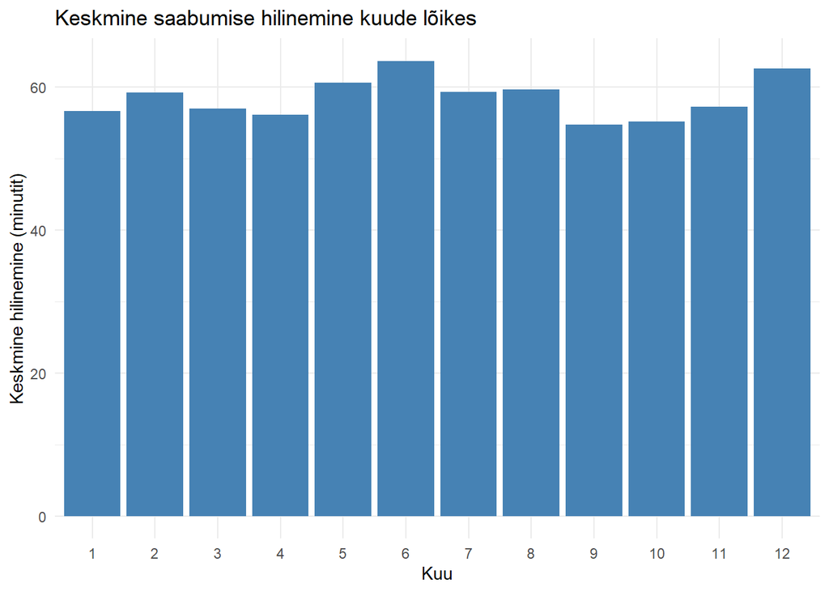

```r
library(ggplot2)

ggplot(flights, aes(x = factor(MONTH), y = ARRIVAL_DELAY)) +
  stat_summary(fun = mean, geom = "bar", fill = "steelblue") +
  labs(title = "Keskmine saabumise hilinemine kuude lõikes",
       x = "Kuu", y = "Keskmine hilinemine (minutit)") +
  theme_minimal()
```

## Kokkuvõte

Nagu näha, on suvekuudel reiside hilinemised tõepoolest veidi suuremad, kuigi mitte märkimisväärselt. Sama kehtib ka detsembri kohta, mil samuti on populaarsed puhkused. Seetõttu võib järeldada, et lennujaamade suurem koormus suvel ja detsembris mõjutab lendude hilinemist küll veidi, kuid mitte oluliselt.

## Tööhüpotees 3: Lennujaama mõju AIRLINE_DELAY

```r
flights_subset <- flights[, c("ORIGIN_AIRPORT", "AIRLINE_DELAY")]
```

```r
flights_subset <- na.omit(flights_subset)
```

### Hüpotees:

**Hüpotees 2**:Lennufirma põhjustatud hilinemise kestus sõltub lähte-lennujaamast. Eeldame, et mõnes lennujaamas on keskmine AIRLINE_DELAY suurem kui teistes.

Et säilitada graafikute ja analüüsi loetavus, keskendume ainult 10 kõige aktiivsemale lennujaamale.

```r
library(dplyr)
top_airports <- flights_subset %>%
  group_by(ORIGIN_AIRPORT) %>%
  summarise(n = n()) %>%
  arrange(desc(n)) %>%
  slice_head(n = 10) %>%
  pull(ORIGIN_AIRPORT)

flights_top <- flights_subset %>%
  filter(ORIGIN_AIRPORT %in% top_airports)
```

Uurime, kuidas erinevad hilinemised lennujaamade lõikes – arvutame keskmised ja hajuvused.

```r
library(FSA)
delay_by_airport <- Summarize(AIRLINE_DELAY ~ ORIGIN_AIRPORT, data = flights_top)
print(delay_by_airport)
```

```
##    ORIGIN_AIRPORT     n     mean       sd min Q1 median Q3  max percZero
## 1             ATL 56462 21.38063 40.56432   0  0      7 26 1126 41.61737
## 2             DEN 43331 17.47892 37.14103   0  0      5 20 1185 41.51993
## 3             DFW 50478 21.17489 39.27934   0  0      7 27  942 39.92036
## 4             IAH 30690 20.03451 40.15548   0  0      6 23 1205 42.76311
## 5             LAS 27225 18.13550 46.84524   0  0      4 18 1593 40.22406
## 6             LAX 40281 17.53924 42.35459   0  0      3 18 1480 44.74318
## 7             LGA 22709 15.60672 40.89173   0  0      0 14  971 53.30486
## 8             ORD 66663 18.91364 38.35365   0  0      3 23 1221 46.22954
## 9             PHX 27427 18.81230 40.96389   0  0      4 21 1366 41.14194
## 10            SFO 29534 18.88528 45.19136   0  0      3 20 1496 46.29918
```

**Järeldus:** Tulemused näitavad, et lennufirma põhjustatud hilinemiste kestus varieerub märgatavalt erinevate lähte-lennujaamade lõikes. Mõnes lennujaamas on keskmised hilinemised kõrgemad ja hajuvus suurem, teistes aga väiksem. Nullhilinemiste osakaal ulatub üle 50%, kuid esineb ka väga pikki hilinemisi. See viitab võimalikule seosele lennujaama ja hilinemise vahel ning õigustab mitteparameetrilise hüpoteesitesti kasutamist.

Kuvame AIRLINE_DELAY karpdiagrammid lennujaamade lõikes, et näha, kas visuaalselt esineb erinevusi hilinemiste tasemetes.

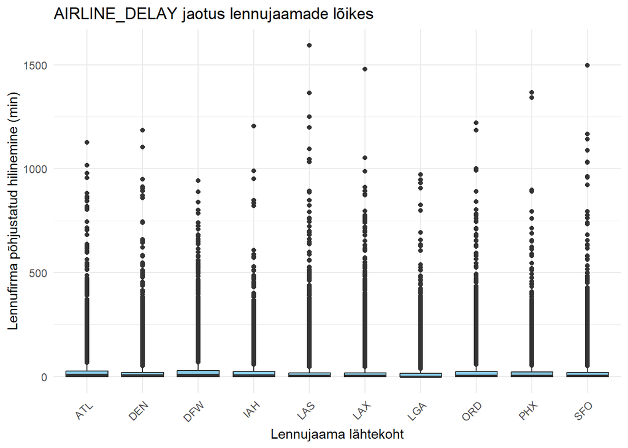

```r
library(ggplot2)
ggplot(flights_top, aes(x = ORIGIN_AIRPORT, y = AIRLINE_DELAY)) +
  geom_boxplot(fill = "skyblue") +
  labs(title = "AIRLINE_DELAY jaotus lennujaamade lõikes",
       x = "Lennujaama lähtekoht",
       y = "Lennufirma põhjustatud hilinemine (min)") +
  theme_minimal() +
  theme(axis.text.x = element_text(angle = 45, hjust = 1))
```

**Järeldus:** Diagrammilt on näha, et erinevates lennujaamades esineb erineva suurusega mediaane ja hajuvust. See toetab hüpoteesi, et lähte-lennujaam võib mõjutada lennufirma põhjustatud hilinemise kestust.

```r
bartlett.test(AIRLINE_DELAY ~ ORIGIN_AIRPORT, data = flights_top)
```

```
##
##  Bartlett test of homogeneity of variances
##
## data:  AIRLINE_DELAY by ORIGIN_AIRPORT
## Bartlett's K-squared = 3286.6, df = 9, p-value < 0.00000000000000022
```

Testi tulemusena saame, et p-väärtus on oluliselt väiksem kui 0.05 (p < 2.2e-16), mis tähendab, et gruppide dispersioonid ei ole homogeensed.

Kuna dispersioonanalüüsi eeldus dispersioonide homogeensusest ei ole täidetud, peame rühmade keskmiste erinevuse testimiseks kasutama mitteparameetrilisi meetodeid, näiteks Kruskal-Wallis testi, mida me allpool juba kasutasime.

```r
kruskal_test <- kruskal.test(AIRLINE_DELAY ~ ORIGIN_AIRPORT, data = flights_top)
print(kruskal_test)
```

```
##
##  Kruskal-Wallis rank sum test
##
## data:  AIRLINE_DELAY by ORIGIN_AIRPORT
## Kruskal-Wallis chi-squared = 2415.4, df = 9, p-value <
## 0.00000000000000022
```

Kruskal-Wallis testi tulemus näitab, et p-väärtus on väiksem kui 0.05 (täpsemalt < 2.2e-16). See tähendab, et rühmade (lendude väljumiskohtade) vahel on lennufirma põhjustatud hilinemise mediaanides statistiliselt olulisi erinevusi. Seega lükatakse nullhüpotees tagasi ning võime järeldada, et lennujaam mõjutab oluliselt lennufirma põhjustatud hilinemiste kestust.